# Ordered Logistic Regression

Megan

2025-03-20

# to do and questions

- Fix OR confidence interval error
- Improve metric - re-run delta pixel eye to foot?
- Re-run with HC as outcome category: HC, mild EDSS, moderate EDSS, and severe EDSS
  - home videos: MS vs mild EDSS vs moderate/severe EDSS (maybe T25fw too?)

-Take out progressive MS as predictor? assumed progressive higher EDSS?

- standardize y limits for probability plots

```r
library(readxl)
library(dplyr)
library(tidyverse)
```

```r
library(ggplot2)
library(foreign)
library(MASS)
library(Hmisc)
library(reshape2)
```

# Set directories and load data

## output directory

```r
# analysis folder
analysis_version <- '005'
```

```r
output_dir <- file.path("C:/Users/mmccu/Box/MM_Personal/5_Projects/BoveLab/3_Data_and_Code/gait_bw_zeno_home_analysis",
                        analysis_version,
                        "003_ordered_logistic_regression_edss")

# create output folder if it doesn't already exist
if (file.exists(output_dir) == FALSE){
  dir.create(output_dir)
}
```

## Load and format PWS data

All videos included in analysis.

Each row = 1 video

```r
# Preferred Walking Speed
zeno_pws_path <- file.path("C:/Users/mmccu/Box/MM_Personal/5_Projects/BoveLab/3_Data_and_Code/gait_bw_zeno_home_analysis",
                           analysis_version,
                           "000_merged_cleaned_data",
                           "zv_bw_merged_gait_vertical_PWS_1_clean.csv")
zeno_pws_df <- read.csv(zeno_pws_path)
table(zeno_pws_df$task_pose)
```

```
##
## gait_vertical_PWS_1
##                 224
```

### Factor categorical vars

```r
str(zeno_pws_df)
```

```
## 'data.frame':    224 obs. of  85 variables:
##  $ X                                          : int  0 1 3 4 5 6 7 8 10 11 ...
##  $ video_id_date_name_pose_zv                 : chr  "gait_vertical_PWS_1_BW-0002_2022_09_12" "gait_vertical_PWS_1_BW-0002_2023_09_12" "gait_vertical_PWS_1_BW-0004_2022_09_19" "gait_vertical_PWS_1_BW-0006_2022_09_26" ...
##  $ id_date_pose_zv                            : chr  "BW-0002\\2022_09_12" "BW-0002\\2023_09_12" "BW-0004\\2022_09_19" "BW-0006\\2022_09_26" ...
##  $ task_pose_zv                               : chr  "gait_vertical_PWS_1" "gait_vertical_PWS_1" "gait_vertical_PWS_1" "gait_vertical_PWS_1" ...
##  $ frames_per_second_pose_zv                  : int  25 30 30 30 30 30 30 30 30 30 ...
##  $ total_video_duration_sec_pose_zv           : num  42.8 46.6 30.4 24.4 27.3 ...
##  $ delta_pix_h_rel_median_pose_zv             : num  0.15 0.22 0.37 0.36 0.26 NA 0.34 NA 0.28 0.27 ...
##  $ walking_segmets_n_pose_zv                  : num  NA 2 NA 2 4 2 2 4 3 3 ...
##  $ walking_segments_duration_mean_pose_zv     : num  NA 5.62 NA 4.65 3.95 4.48 4.55 6.94 3.6 4.79 ...
##  $ walking_segments_duration_median_pose_zv   : num  NA 5.62 NA 4.65 4.05 4.48 4.55 6.88 3.93 5 ...
##  $ stride_time_mean_sec_pose_zv               : num  NA 1.47 NA 1.15 1.17 ...
##  $ stride_time_median_sec_pose_zv             : num  NA 1.5 NA 1.17 1.17 ...
##  $ stride_time_std_pose_zv                    : num  NA 0.254 NA 0.134 0.116 0.09 0.048 0.081 0.166 0.143 ...
##  $ stride_time_cv_pose_zv                     : num  NA 17.26 NA 11.71 9.84 ...
```

[output cut: 71 more lines]

```r
zeno_pws_df <- zeno_pws_df %>%
  mutate_at(c("video_id_date_name_pose_zv", "id_date_pose_zv", "task_pose_zv",
              "id_video", "bw_id", "clean_sex", "bingoEHR_DX_MS.DX",
              "demographic_diagnosis", "race_ethnicity_clean",
              "race_ethnicity_clean", "ms_dx_condensed",
              "redcap_event_name", "bingoEHR_EDSS_measure_value"),
            as.factor)
str(zeno_pws_df)
```

```
## 'data.frame':    224 obs. of  85 variables:
##  $ X                                          : int  0 1 3 4 5 6 7 8 10 11 ...
##  $ video_id_date_name_pose_zv                 : Factor w/ 224 levels "gait_vertical_PWS_1_BW-0002_2022_09_12",..: 1 2 3 4 5 6 7 8 9 10 ...
##  $ id_date_pose_zv                            : Factor w/ 224 levels "BW-0002\\2022_09_12",..: 1 2 3 4 5 6 7 8 9 10 ...
##  $ task_pose_zv                               : Factor w/ 1 level "gait_vertical_PWS_1": 1 1 1 1 1 1 1 1 1 1 ...
##  $ frames_per_second_pose_zv                  : int  25 30 30 30 30 30 30 30 30 30 ...
##  $ total_video_duration_sec_pose_zv           : num  42.8 46.6 30.4 24.4 27.3 ...
##  $ delta_pix_h_rel_median_pose_zv             : num  0.15 0.22 0.37 0.36 0.26 NA 0.34 NA 0.28 0.27 ...
##  $ walking_segmets_n_pose_zv                  : num  NA 2 NA 2 4 2 2 4 3 3 ...
##  $ walking_segments_duration_mean_pose_zv     : num  NA 5.62 NA 4.65 3.95 4.48 4.55 6.94 3.6 4.79 ...
##  $ walking_segments_duration_median_pose_zv   : num  NA 5.62 NA 4.65 4.05 4.48 4.55 6.88 3.93 5 ...
##  $ stride_time_mean_sec_pose_zv               : num  NA 1.47 NA 1.15 1.17 ...
##  $ stride_time_median_sec_pose_zv             : num  NA 1.5 NA 1.17 1.17 ...
##  $ stride_time_std_pose_zv                    : num  NA 0.254 NA 0.134 0.116 0.09 0.048 0.081 0.166 0.143 ...
##  $ stride_time_cv_pose_zv                     : num  NA 17.26 NA 11.71 9.84 ...
```

[output cut: 71 more lines]

```r
# assign levels to categorical variables
table(zeno_pws_df$race_ethnicity_clean)
```

```
##
##                     Asian Black Or African American        Hispanic or Latino
##                        17                        14                        21
##    Other/Unknown/Declined        White Not Hispanic
##                        18                       154
```

```r
zeno_pws_df$race_ethnicity_clean <- factor(zeno_pws_df$race_ethnicity_clean,
                                           levels = c('White Not Hispanic',
                                                      'Asian',
                                                      'Black Or African American',
                                                      'Hispanic or Latino',
                                                      'Other/Unknown/Declined'),
                                           ordered = FALSE)
print(levels(zeno_pws_df$race_ethnicity_clean))
```

```
## [1] "White Not Hispanic"        "Asian"
## [3] "Black Or African American" "Hispanic or Latino"
## [5] "Other/Unknown/Declined"
```

```r
table(zeno_pws_df$ms_dx_condensed)
```

```
##
## MS, Subtype Not Specified            Progressive MS                      RRMS
##                         3                        40                       181
```

```r
zeno_pws_df$ms_dx_condensed <- factor(zeno_pws_df$ms_dx_condensed,
                                      levels = c('RRMS',
                                                 'Progressive MS',
                                                 'MS, Subtype Not Specified'),
                                      ordered = FALSE)
print(levels(zeno_pws_df$ms_dx_condensed))
```

```
## [1] "RRMS"                      "Progressive MS"
## [3] "MS, Subtype Not Specified"
```

```r
table(zeno_pws_df$clean_sex)
```

```
##
##     Female       Male Non-Binary
##        168         54          2
```

```r
zeno_pws_df$clean_sex <- factor(zeno_pws_df$clean_sex,
                                levels = c('Female',
                                           'Male',
                                           'Non-Binary'),
                                ordered = FALSE)
print(levels(zeno_pws_df$clean_sex))
```

```
## [1] "Female"     "Male"       "Non-Binary"
```

```r
table(zeno_pws_df$edss_severity_cat)
```

```
##
##     mild moderate   severe
##       99       81       44
```

```r
zeno_pws_df$edss_severity_cat <- factor(zeno_pws_df$edss_severity_cat,
                                        levels = c('mild',
                                                   'moderate',
                                                   'severe'),
                                        ordered = TRUE)
print(levels(zeno_pws_df$edss_severity_cat))
```

```
## [1] "mild"     "moderate" "severe"
```

```r
print(table(zeno_pws_df$edss_severity_cat))
```

```
##
##     mild moderate   severe
##       99       81       44
```

### Merge small categorical groups

```r
#MS DX
print(levels(zeno_pws_df$ms_dx_condensed))
```

```
## [1] "RRMS"                      "Progressive MS"
## [3] "MS, Subtype Not Specified"
```

```r
zeno_pws_df <- zeno_pws_df %>%
  mutate(ms_dx_condensed_2 = if_else(ms_dx_condensed == "Progressive MS",
                                     "Progressive MS",
                                     "RRMS or Not Specified"))

zeno_pws_df$ms_dx_condensed_2 <- factor(zeno_pws_df$ms_dx_condensed_2,
                                        levels = c("RRMS or Not Specified",
                                                   "Progressive MS"),
                                        ordered = FALSE)


table(zeno_pws_df$ms_dx_condensed_2)
```

```
##
## RRMS or Not Specified        Progressive MS
##                   184                    40
```

```r
print(str(zeno_pws_df$ms_dx_condensed_2))
```

```
##  Factor w/ 2 levels "RRMS or Not Specified",..: 1 1 1 2 1 1 2 2 1 1 ...
## NULL
```

```r
# race_ethnicity
print(table(zeno_pws_df$race_ethnicity_clean))
```

```
##
##        White Not Hispanic                     Asian Black Or African American
##                       154                        17                        14
##        Hispanic or Latino    Other/Unknown/Declined
##                        21                        18
```

```r
zeno_pws_df <- zeno_pws_df %>%
  mutate(race_ethnicity_clean_2 = if_else(zeno_pws_df$race_ethnicity_clean %in% c("Asian", "Black Or African American"),
                                          "Asian or Black or African American",
                                          zeno_pws_df$race_ethnicity_clean))

print(table(zeno_pws_df$race_ethnicity_clean_2))
```

```
##
## Asian or Black or African American                 Hispanic or Latino
##                                 31                                 21
##             Other/Unknown/Declined                 White Not Hispanic
##                                 18                                154
```

```r
zeno_pws_df$race_ethnicity_clean_2 <- factor(zeno_pws_df$race_ethnicity_clean_2,
                                           levels = c('White Not Hispanic',
                                                      'Asian or Black or African American',
                                                      'Hispanic or Latino',
                                                      'Other/Unknown/Declined'),
                                           ordered = FALSE)
print(levels(zeno_pws_df$race_ethnicity_clean_2))
```

```
## [1] "White Not Hispanic"                 "Asian or Black or African American"
## [3] "Hispanic or Latino"                 "Other/Unknown/Declined"
```

```r
table(zeno_pws_df$race_ethnicity_clean_2)
```

```
##
##                 White Not Hispanic Asian or Black or African American
##                                154                                 31
##                 Hispanic or Latino             Other/Unknown/Declined
##                                 21                                 18
```

```r
# clean_sex
print(table(zeno_pws_df$clean_sex))
```

```
##
##     Female       Male Non-Binary
##        168         54          2
```

```r
zeno_pws_df <- zeno_pws_df %>%
  mutate(clean_sex_2 = if_else(clean_sex == "Female",
                                     "Female",
                                     "Male or Non-Binary"))

zeno_pws_df$clean_sex_2 <- factor(zeno_pws_df$clean_sex_2,
                                        levels = c("Female",
                                                   "Male or Non-Binary"),
                                        ordered = FALSE)


table(zeno_pws_df$clean_sex_2)
```

```
##
##             Female Male or Non-Binary
##                168                 56
```

```r
print(str(zeno_pws_df$clean_sex_2))
```

```
##  Factor w/ 2 levels "Female","Male or Non-Binary": 2 2 1 1 1 1 2 2 1 1 ...
## NULL
```

### missing variables in each column

```r
colSums(is.na(zeno_pws_df))
```

```
##                                           X
##                                           0
##                  video_id_date_name_pose_zv
##                                           0
##                             id_date_pose_zv
##                                           0
##                                task_pose_zv
##                                           0
##                   frames_per_second_pose_zv
##                                           0
##            total_video_duration_sec_pose_zv
##                                           0
##              delta_pix_h_rel_median_pose_zv
##                                          16
##                   walking_segmets_n_pose_zv
##                                          40
##      walking_segments_duration_mean_pose_zv
##                                          40
##    walking_segments_duration_median_pose_zv
##                                          40
##                stride_time_mean_sec_pose_zv
##                                          48
##              stride_time_median_sec_pose_zv
##                                          48
##                     stride_time_std_pose_zv
##                                          53
##                      stride_time_cv_pose_zv
##                                          53
##                     stride_time_max_pose_zv
##                                          48
##                     stride_time_min_pose_zv
##                                          48
##           mean_cadence_step_per_min_pose_zv
##                                          40
##                stride_width_mean_cm_pose_zv
##                                          40
##              stride_width_median_cm_pose_zv
##                                          40
##                    stride_width_std_pose_zv
##                                          42
```

[output cut: 121 more lines]

```
##                                           0
##                             t25fw_group_num
##                                           0
##                             t25fw_group_cat
##                                           0
##                        race_ethnicity_clean
##                                           0
##                             ms_dx_condensed
##                                           0
##                           ms_dx_condensed_2
##                                           0
##                      race_ethnicity_clean_2
##                                           0
##                                 clean_sex_2
##                                           0
```

### Visit types

```r
table(zeno_pws_df$redcap_event_name)
```

```
##
## Brainwalk: Baseline visit (Arm 1: Baseline visit)
##                                               138
##              Year 2 Visit (Arm 1: Baseline visit)
##                                                78
##              Year 3 Visit (Arm 1: Baseline visit)
##                                                 7
##              Year 4 Visit (Arm 1: Baseline visit)
##                                                 1
```

## Load and format FW data

All videos included in analysis.

Each row = 1 video

```r
zeno_fw_path <- file.path("C:/Users/mmccu/Box/MM_Personal/5_Projects/BoveLab/3_Data_and_Code/gait_bw_zeno_home_analysis",
                          analysis_version,
                          "000_merged_cleaned_data",
                          "zv_bw_merged_gait_vertical_FW_1_clean.csv")
zeno_fw_df <- read.csv(zeno_fw_path)
table(zeno_fw_df$task_pose)
```

```
##
## gait_vertical_FW_1
##                222
```

### Factor categorical vars

```r
str(zeno_fw_df)
```

```
## 'data.frame':    222 obs. of  85 variables:
##  $ X                                          : int  0 1 3 4 5 6 8 9 11 12 ...
##  $ video_id_date_name_pose_zv                 : chr  "gait_vertical_FW_1_BW-0002_2022_09_12" "gait_vertical_FW_1_BW-0002_2023_09_12" "gait_vertical_FW_1_BW-0004_2022_09_19" "gait_vertical_FW_1_BW-0006_2022_09_26" ...
##  $ id_date_pose_zv                            : chr  "BW-0002\\2022_09_12" "BW-0002\\2023_09_12" "BW-0004\\2022_09_19" "BW-0006\\2022_09_26" ...
##  $ task_pose_zv                               : chr  "gait_vertical_FW_1" "gait_vertical_FW_1" "gait_vertical_FW_1" "gait_vertical_FW_1" ...
##  $ frames_per_second_pose_zv                  : int  25 30 30 30 30 30 30 30 30 30 ...
##  $ total_video_duration_sec_pose_zv           : num  29 36.5 25.3 25 22.6 ...
##  $ delta_pix_h_rel_median_pose_zv             : num  0.28 0.25 0.36 0.27 0.43 0.23 0.44 0.35 0.44 0.29 ...
##  $ walking_segmets_n_pose_zv                  : num  NA 2 2 1 4 4 3 3 2 2 ...
##  $ walking_segments_duration_mean_pose_zv     : num  NA 5.23 2.47 4.87 3.48 4.79 2.38 4.44 4.63 4.27 ...
##  $ walking_segments_duration_median_pose_zv   : num  NA 5.23 2.47 4.87 3.47 4.97 2.1 4.4 4.63 4.27 ...
##  $ stride_time_mean_sec_pose_zv               : num  NA 1.007 1.433 0.957 1.027 ...
##  $ stride_time_median_sec_pose_zv             : num  NA 1.067 1.333 0.967 0.933 ...
##  $ stride_time_std_pose_zv                    : num  NA 0.266 0.233 0.037 0.189 0.126 0.052 0.101 0.066 0.055 ...
##  $ stride_time_cv_pose_zv                     : num  NA 26.44 16.28 3.88 18.38 ...
```

[output cut: 71 more lines]

```r
zeno_fw_df <- zeno_fw_df %>%
  mutate_at(c("video_id_date_name_pose_zv", "id_date_pose_zv", "task_pose_zv",
              "id_video", "bw_id", "clean_sex", "bingoEHR_DX_MS.DX",
              "demographic_diagnosis", "race_ethnicity_clean",
              "race_ethnicity_clean", "ms_dx_condensed",
              "redcap_event_name", "bingoEHR_EDSS_measure_value"),
            as.factor)
str(zeno_fw_df)
```

```
## 'data.frame':    222 obs. of  85 variables:
##  $ X                                          : int  0 1 3 4 5 6 8 9 11 12 ...
##  $ video_id_date_name_pose_zv                 : Factor w/ 222 levels "gait_vertical_FW_1_BW-0002_2022_09_12",..: 1 2 3 4 5 6 7 8 9 10 ...
##  $ id_date_pose_zv                            : Factor w/ 222 levels "BW-0002\\2022_09_12",..: 1 2 3 4 5 6 7 8 9 10 ...
##  $ task_pose_zv                               : Factor w/ 1 level "gait_vertical_FW_1": 1 1 1 1 1 1 1 1 1 1 ...
##  $ frames_per_second_pose_zv                  : int  25 30 30 30 30 30 30 30 30 30 ...
##  $ total_video_duration_sec_pose_zv           : num  29 36.5 25.3 25 22.6 ...
##  $ delta_pix_h_rel_median_pose_zv             : num  0.28 0.25 0.36 0.27 0.43 0.23 0.44 0.35 0.44 0.29 ...
##  $ walking_segmets_n_pose_zv                  : num  NA 2 2 1 4 4 3 3 2 2 ...
##  $ walking_segments_duration_mean_pose_zv     : num  NA 5.23 2.47 4.87 3.48 4.79 2.38 4.44 4.63 4.27 ...
##  $ walking_segments_duration_median_pose_zv   : num  NA 5.23 2.47 4.87 3.47 4.97 2.1 4.4 4.63 4.27 ...
##  $ stride_time_mean_sec_pose_zv               : num  NA 1.007 1.433 0.957 1.027 ...
##  $ stride_time_median_sec_pose_zv             : num  NA 1.067 1.333 0.967 0.933 ...
##  $ stride_time_std_pose_zv                    : num  NA 0.266 0.233 0.037 0.189 0.126 0.052 0.101 0.066 0.055 ...
##  $ stride_time_cv_pose_zv                     : num  NA 26.44 16.28 3.88 18.38 ...
```

[output cut: 71 more lines]

```r
# assign levels to categorical variables
table(zeno_fw_df$race_ethnicity_clean)
```

```
##
##                     Asian Black Or African American        Hispanic or Latino
##                        17                        14                        20
##    Other/Unknown/Declined        White Not Hispanic
##                        18                       153
```

```r
zeno_fw_df$race_ethnicity_clean <- factor(zeno_fw_df$race_ethnicity_clean,
                                          levels = c('White Not Hispanic',
                                                     'Asian',
                                                     'Black Or African American',
                                                     'Hispanic or Latino',
                                                     'Other/Unknown/Declined'),
                                          ordered = FALSE)
print(levels(zeno_fw_df$race_ethnicity_clean))
```

```
## [1] "White Not Hispanic"        "Asian"
## [3] "Black Or African American" "Hispanic or Latino"
## [5] "Other/Unknown/Declined"
```

```r
table(zeno_fw_df$ms_dx_condensed)
```

```
##
## MS, Subtype Not Specified            Progressive MS                      RRMS
##                         2                        39                       181
```

```r
zeno_fw_df$ms_dx_condensed <- factor(zeno_fw_df$ms_dx_condensed,
                                     levels = c('RRMS',
                                                'Progressive MS',
                                                'MS, Subtype Not Specified'),
                                     ordered = FALSE)
print(levels(zeno_fw_df$ms_dx_condensed))
```

```
## [1] "RRMS"                      "Progressive MS"
## [3] "MS, Subtype Not Specified"
```

```r
table(zeno_fw_df$clean_sex)
```

```
##
##     Female       Male Non-Binary
##        167         53          2
```

```r
zeno_fw_df$clean_sex <- factor(zeno_fw_df$clean_sex,
                               levels = c('Female',
                                          'Male',
                                          'Non-Binary'),
                               ordered = FALSE)
print(levels(zeno_fw_df$clean_sex))
```

```
## [1] "Female"     "Male"       "Non-Binary"
```

```r
table(zeno_fw_df$edss_severity_cat)
```

```
##
##     mild moderate   severe
##       99       82       41
```

```r
zeno_fw_df$edss_severity_cat <- factor(zeno_fw_df$edss_severity_cat,
                                levels = c('mild',
                                           'moderate',
                                           'severe'),
                                ordered = TRUE)
print(levels(zeno_fw_df$edss_severity_cat))
```

```
## [1] "mild"     "moderate" "severe"
```

### Merge small categorical groups

```r
#MS DX
print(levels(zeno_fw_df$ms_dx_condensed))
```

```
## [1] "RRMS"                      "Progressive MS"
## [3] "MS, Subtype Not Specified"
```

```r
zeno_fw_df <- zeno_fw_df %>%
  mutate(ms_dx_condensed_2 = if_else(ms_dx_condensed == "Progressive MS",
                                     "Progressive MS",
                                     "RRMS or Not Specified"))

zeno_fw_df$ms_dx_condensed_2 <- factor(zeno_fw_df$ms_dx_condensed_2,
                                        levels = c("RRMS or Not Specified",
                                                   "Progressive MS"),
                                        ordered = FALSE)


table(zeno_fw_df$ms_dx_condensed_2)
```

```
##
## RRMS or Not Specified        Progressive MS
##                   183                    39
```

```r
print(str(zeno_fw_df$ms_dx_condensed_2))
```

```
##  Factor w/ 2 levels "RRMS or Not Specified",..: 1 1 1 2 1 1 2 2 1 1 ...
## NULL
```

```r
# race_ethnicity
print(table(zeno_fw_df$race_ethnicity_clean))
```

```
##
##        White Not Hispanic                     Asian Black Or African American
##                       153                        17                        14
##        Hispanic or Latino    Other/Unknown/Declined
##                        20                        18
```

```r
zeno_fw_df <- zeno_fw_df %>%
  mutate(race_ethnicity_clean_2 = if_else(zeno_fw_df$race_ethnicity_clean %in% c("Asian", "Black Or African American"),
                                          "Asian or Black or African American",
                                          zeno_fw_df$race_ethnicity_clean))
print(table(zeno_fw_df$race_ethnicity_clean_2))
```

```
##
## Asian or Black or African American                 Hispanic or Latino
##                                 31                                 20
##             Other/Unknown/Declined                 White Not Hispanic
##                                 18                                153
```

```r
zeno_fw_df$race_ethnicity_clean_2 <- factor(zeno_fw_df$race_ethnicity_clean_2,
                                           levels = c('White Not Hispanic',
                                                      'Asian or Black or African American',
                                                      'Hispanic or Latino',
                                                      'Other/Unknown/Declined'),
                                           ordered = FALSE)
print(levels(zeno_fw_df$race_ethnicity_clean_2))
```

```
## [1] "White Not Hispanic"                 "Asian or Black or African American"
## [3] "Hispanic or Latino"                 "Other/Unknown/Declined"
```

```r
table(zeno_fw_df$race_ethnicity_clean_2)
```

```
##
##                 White Not Hispanic Asian or Black or African American
##                                153                                 31
##                 Hispanic or Latino             Other/Unknown/Declined
##                                 20                                 18
```

```r
# clean_sex
print(table(zeno_fw_df$clean_sex))
```

```
##
##     Female       Male Non-Binary
##        167         53          2
```

```r
zeno_fw_df <- zeno_fw_df %>%
  mutate(clean_sex_2 = if_else(clean_sex == "Female",
                                     "Female",
                                     "Male or Non-Binary"))

zeno_fw_df$clean_sex_2 <- factor(zeno_fw_df$clean_sex_2,
                                        levels = c("Female",
                                                   "Male or Non-Binary"),
                                        ordered = FALSE)


table(zeno_fw_df$clean_sex_2)
```

```
##
##             Female Male or Non-Binary
##                167                 55
```

```r
print(str(zeno_fw_df$clean_sex_2))
```

```
##  Factor w/ 2 levels "Female","Male or Non-Binary": 2 2 1 1 1 1 2 2 1 1 ...
## NULL
```

### Missing variables per column

```r
colSums(is.na(zeno_fw_df))
```

```
##                                           X
##                                           0
##                  video_id_date_name_pose_zv
##                                           0
##                             id_date_pose_zv
##                                           0
##                                task_pose_zv
##                                           0
##                   frames_per_second_pose_zv
##                                           0
##            total_video_duration_sec_pose_zv
##                                           0
##              delta_pix_h_rel_median_pose_zv
##                                           3
##                   walking_segmets_n_pose_zv
##                                          46
##      walking_segments_duration_mean_pose_zv
##                                          46
##    walking_segments_duration_median_pose_zv
##                                          46
##                stride_time_mean_sec_pose_zv
##                                          53
##              stride_time_median_sec_pose_zv
##                                          53
##                     stride_time_std_pose_zv
##                                          54
##                      stride_time_cv_pose_zv
##                                          54
##                     stride_time_max_pose_zv
##                                          53
##                     stride_time_min_pose_zv
##                                          53
##           mean_cadence_step_per_min_pose_zv
##                                          46
##                stride_width_mean_cm_pose_zv
##                                          47
##              stride_width_median_cm_pose_zv
##                                          47
##                    stride_width_std_pose_zv
##                                          49
```

[output cut: 121 more lines]

```
##                                           0
##                             t25fw_group_num
##                                           0
##                             t25fw_group_cat
##                                           0
##                        race_ethnicity_clean
##                                           0
##                             ms_dx_condensed
##                                           0
##                           ms_dx_condensed_2
##                                           0
##                      race_ethnicity_clean_2
##                                           0
##                                 clean_sex_2
##                                           0
```

### Visit types

```r
table(zeno_fw_df$redcap_event_name)
```

```
##
## Brainwalk: Baseline visit (Arm 1: Baseline visit)
##                                               139
##              Year 2 Visit (Arm 1: Baseline visit)
##                                                75
##              Year 3 Visit (Arm 1: Baseline visit)
##                                                 7
##              Year 4 Visit (Arm 1: Baseline visit)
##                                                 1
```

## Load and format Home video data

```r
home_path <- file.path("C:/Users/mmccu/Box/MM_Personal/5_Projects/BoveLab/3_Data_and_Code/gait_bw_zeno_home_analysis",
                       analysis_version,
                       "000_merged_cleaned_data",
                       "hv_bw_merged_clean.csv")
home_df <- read.csv(home_path)
nrow(home_df)
```

```
## [1] 65
```

```r
table(home_df$demographic_diagnosis)
```

```
##
## MS
## 65
```

```r
table(home_df$task_pose_hv)
```

```
##
##  gait_vertical_left gait_vertical_right
##                  32                  33
```

### Factor categorical vars

```r
str(home_df)
```

```
## 'data.frame':    65 obs. of  86 variables:
##  $ X                                          : int  0 1 2 3 4 5 6 8 10 11 ...
##  $ video_id_date_name_pose_hv                 : chr  "gait_vertical_left_BW-0018_10-24-23" "gait_vertical_right_BW-0018_10-24-23" "gait_vertical_left_BW-0023_05-05-23" "gait_vertical_right_BW-0023_05-05-23" ...
##  $ id_date_pose_hv                            : chr  "BW-0018\\10-24-23" "BW-0018\\10-24-23" "BW-0023\\05-05-23" "BW-0023\\05-05-23" ...
##  $ task_pose_hv                               : chr  "gait_vertical_left" "gait_vertical_right" "gait_vertical_left" "gait_vertical_right" ...
##  $ frames_per_second_pose_hv                  : int  30 30 30 30 30 30 30 30 30 30 ...
##  $ total_video_duration_sec_pose_hv           : num  26.8 24.4 36 38.5 36.1 ...
##  $ delta_pix_h_rel_median_pose_hv             : num  0.22 0.31 0.43 0.39 0.3 0.39 0.03 0.08 0.22 0.24 ...
##  $ walking_segmets_n_pose_hv                  : num  1 1 4 5 3 2 NA NA 5 5 ...
##  $ walking_segments_duration_mean_pose_hv     : num  3.17 2.4 4.42 4.78 4.19 5.07 NA NA 4.47 3.77 ...
##  $ walking_segments_duration_median_pose_hv   : num  3.17 2.4 4.33 4.63 3.83 5.07 NA NA 4.3 3.7 ...
##  $ stride_time_mean_sec_pose_hv               : num  1.008 NA 1.027 1.07 0.998 ...
##  $ stride_time_median_sec_pose_hv             : num  1.05 NA 1.033 1.033 0.983 ...
##  $ stride_time_std_pose_hv                    : num  0.171 NA 0.066 0.098 0.087 0.076 NA NA 0.229 0.078 ...
##  $ stride_time_cv_pose_hv                     : num  16.94 NA 6.46 9.11 8.74 ...
```

[output cut: 72 more lines]

```r
home_df <- home_df %>%
  mutate_at(c("video_id_date_name_pose_hv", "id_date_pose_hv", "task_pose_hv",
              "id_video", "bw_id", "clean_sex", "bingoEHR_DX_MS.DX",
              "demographic_diagnosis", "race_ethnicity_clean",
              "race_ethnicity_clean", "ms_dx_condensed",
              "redcap_event_name", "bingoEHR_EDSS_measure_value"),
            as.factor)
str(home_df)
```

```
## 'data.frame':    65 obs. of  86 variables:
##  $ X                                          : int  0 1 2 3 4 5 6 8 10 11 ...
##  $ video_id_date_name_pose_hv                 : Factor w/ 65 levels "gait_vertical_left_BW-0018_10-24-23",..: 1 33 2 34 3 35 4 36 5 37 ...
##  $ id_date_pose_hv                            : Factor w/ 35 levels "BW-0018\\10-24-23",..: 1 1 2 2 3 3 4 4 5 5 ...
##  $ task_pose_hv                               : Factor w/ 2 levels "gait_vertical_left",..: 1 2 1 2 1 2 1 2 1 2 ...
##  $ frames_per_second_pose_hv                  : int  30 30 30 30 30 30 30 30 30 30 ...
##  $ total_video_duration_sec_pose_hv           : num  26.8 24.4 36 38.5 36.1 ...
##  $ delta_pix_h_rel_median_pose_hv             : num  0.22 0.31 0.43 0.39 0.3 0.39 0.03 0.08 0.22 0.24 ...
##  $ walking_segmets_n_pose_hv                  : num  1 1 4 5 3 2 NA NA 5 5 ...
##  $ walking_segments_duration_mean_pose_hv     : num  3.17 2.4 4.42 4.78 4.19 5.07 NA NA 4.47 3.77 ...
##  $ walking_segments_duration_median_pose_hv   : num  3.17 2.4 4.33 4.63 3.83 5.07 NA NA 4.3 3.7 ...
##  $ stride_time_mean_sec_pose_hv               : num  1.008 NA 1.027 1.07 0.998 ...
##  $ stride_time_median_sec_pose_hv             : num  1.05 NA 1.033 1.033 0.983 ...
##  $ stride_time_std_pose_hv                    : num  0.171 NA 0.066 0.098 0.087 0.076 NA NA 0.229 0.078 ...
##  $ stride_time_cv_pose_hv                     : num  16.94 NA 6.46 9.11 8.74 ...
```

[output cut: 72 more lines]

```r
# assign levels to categorical variables
table(home_df$race_ethnicity_clean)
```

```
##
##                     Asian Black Or African American        Hispanic or Latino
##                         4                         2                         2
##    Other/Unknown/Declined        White Not Hispanic
##                         9                        48
```

```r
home_df$race_ethnicity_clean <- factor(home_df$race_ethnicity_clean,
                                       levels = c('White Not Hispanic',
                                                  'Asian',
                                                  'Black Or African American',
                                                  'Hispanic or Latino',
                                                  'Other/Unknown/Declined'),
                                       ordered = FALSE)
print(levels(home_df$race_ethnicity_clean))
```

```
## [1] "White Not Hispanic"        "Asian"
## [3] "Black Or African American" "Hispanic or Latino"
## [5] "Other/Unknown/Declined"
```

```r
table(home_df$ms_dx_condensed)
```

```
##
## MS, Subtype Not Specified            Progressive MS                      RRMS
##                         4                         9                        52
```

```r
home_df$ms_dx_condensed <- factor(home_df$ms_dx_condensed,
                                  levels = c('RRMS',
                                             'Progressive MS',
                                             'MS, Subtype Not Specified'),
                                  ordered = FALSE)
print(levels(zeno_fw_df$ms_dx_condensed))
```

```
## [1] "RRMS"                      "Progressive MS"
## [3] "MS, Subtype Not Specified"
```

```r
table(zeno_fw_df$clean_sex)
```

```
##
##     Female       Male Non-Binary
##        167         53          2
```

```r
zeno_fw_df$clean_sex <- factor(zeno_fw_df$clean_sex,
                               levels = c('Female',
                                          'Male',
                                          'Non-Binary'),
                               ordered = FALSE)
print(levels(home_df$clean_sex))
```

```
## [1] "Female"     "Male"       "Non-Binary"
```

```r
table(home_df$edss_severity_cat)
```

```
##
##     mild moderate   severe
##       23       20       22
```

```r
home_df$edss_severity_cat <- factor(home_df$edss_severity_cat,
                                levels = c('mild',
                                           'moderate',
                                           'severe'),
                                ordered = TRUE)
print(levels(home_df$edss_severity_cat))
```

```
## [1] "mild"     "moderate" "severe"
```

### Missing variables per column

```r
colSums(is.na(home_df))
```

```
##                                           X
##                                           0
##                  video_id_date_name_pose_hv
##                                           0
##                             id_date_pose_hv
##                                           0
##                                task_pose_hv
##                                           0
##                   frames_per_second_pose_hv
##                                           0
##            total_video_duration_sec_pose_hv
##                                           0
##              delta_pix_h_rel_median_pose_hv
##                                           4
##                   walking_segmets_n_pose_hv
##                                          12
##      walking_segments_duration_mean_pose_hv
##                                          12
##    walking_segments_duration_median_pose_hv
##                                          12
##                stride_time_mean_sec_pose_hv
##                                          13
##              stride_time_median_sec_pose_hv
##                                          13
##                     stride_time_std_pose_hv
##                                          14
##                      stride_time_cv_pose_hv
##                                          14
##                     stride_time_max_pose_hv
##                                          13
##                     stride_time_min_pose_hv
##                                          13
##           mean_cadence_step_per_min_pose_hv
##                                          12
##                stride_width_mean_cm_pose_hv
##                                          12
##              stride_width_median_cm_pose_hv
##                                          12
##                    stride_width_std_pose_hv
##                                          12
```

[output cut: 117 more lines]

```
##                                           0
##                           edss_severity_num
##                                           0
##                           edss_severity_cat
##                                           0
##                             t25fw_group_num
##                                           0
##                             t25fw_group_cat
##                                           0
##                        race_ethnicity_clean
##                                           0
##                             ms_dx_condensed
##                                           0
##                        bw_hv_date_diff_days
##                                           0
```

### Visit types

```r
# of right turning videos and left turning videos
table(home_df$task_pose_hv)
```

```
##
##  gait_vertical_left gait_vertical_right
##                  32                  33
```

```r
# videos per timepoint - most people sent two videos per timepoint
# some sent first videos at year 2 or year 3 visit, not necessarily a true follow up
table(home_df$redcap_event_name)
```

```
##
## Brainwalk: Baseline visit (Arm 1: Baseline visit)
##                                                38
##              Year 2 Visit (Arm 1: Baseline visit)
##                                                23
##              Year 3 Visit (Arm 1: Baseline visit)
##                                                 4
```

### Date diff histograms

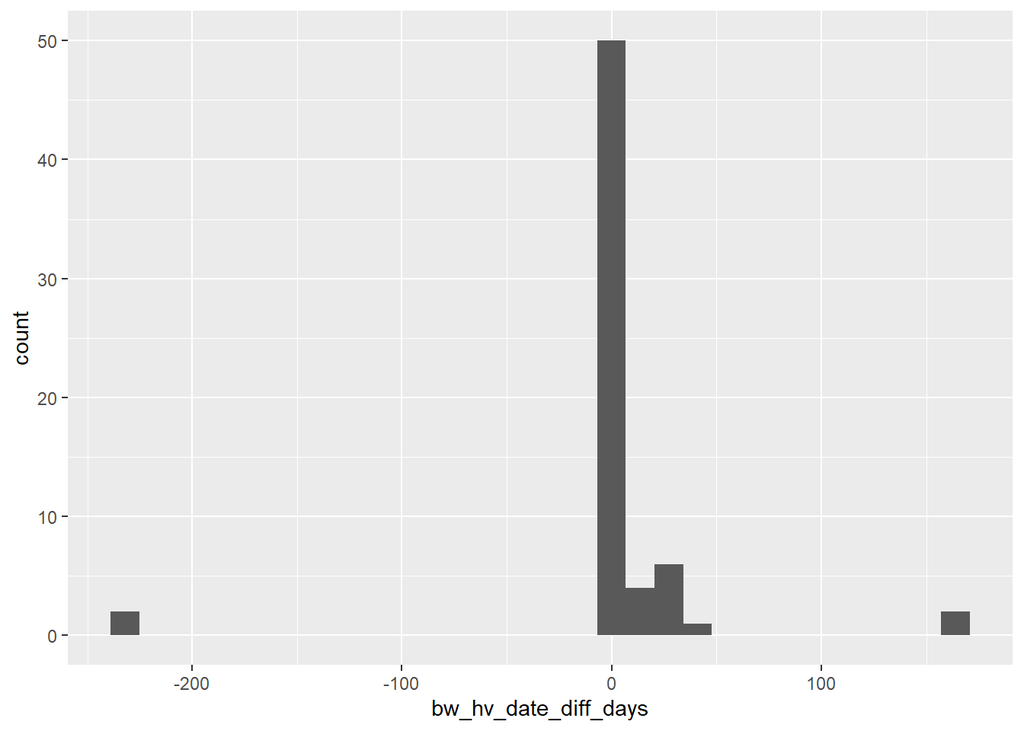

```r
ggplot(data = home_df, aes(bw_hv_date_diff_days)) +
  geom_histogram()
```

# Functions

## Summarize and save polr results

```r
summary_calc_p_and_odds <- function(polr_object, file_name) {

  print(summary(polr_object))

  # calculate p-value by comparing t-value vs standard normal distribution
  ctable1 <- coef(summary(polr_object))
  ## calculate and store p values
  p <- pnorm(abs(ctable1[, "t value"]), lower.tail = FALSE) * 2

  ## combined table
  print('Add p-value')
  print((ctable1 <- cbind(ctable1, "p.value" = p)))
  write.csv(ctable1, file.path(output_dir, paste(file_name, "estimates.csv", sep = "_")))

  # confidence intervals
  ci <- confint(polr_object)
  print(ci[1])

  ## OR and CI
  print('Odds Ratio and CI')
  OR <- exp(cbind("OR" = coef(polr_object), "ci_2.5%" = ci[1], "ci_97.5%"= ci[2]))
  print(OR)
  write.csv(OR, file.path(output_dir, paste(file_name, "odds_ratio.csv", sep = "_")))

}
```

## Test proportional odds assumption

```r
# calculate the log odds of being greater than or equal to each value of the target variable
sf <- function(y) {
  c('Y>=1' = qlogis(mean(y >= 1)),
    'Y>=2' = qlogis(mean(y >= 2)),
    'Y>=3' = qlogis(mean(y >= 3)))
}
```

```r
plot_check_assumption <- function(s_var) {
  # we normalized all the first set of coefficients to be zero so there is a common reference point.
  # for each variable - is horizontal distance between variables similar?
  # if so, proportional odds assumption likeley holds
  # if not, proportional odss assumption may not hold

  s[, 4] <- s[, 4] - s[, 3]
  s[, 3] <- s[, 3] - s[, 3]
  print(s) # print

  p <- plot(s, which=1:3, pch=1:3, xlab='logit', main=' ', xlim=range(s[,3:4]))
  return(p)
  }
```

# Transform Velocity Proxy

log transform to improve linearity and replace inf values with NA

```r
zeno_pws_df$log_delta_pix_h_rel_median_pose_zv <- log(zeno_pws_df$delta_pix_h_rel_median_pose_zv)
zeno_fw_df$log_delta_pix_h_rel_median_pose_zv <- log(zeno_fw_df$delta_pix_h_rel_median_pose_zv)
home_df$log_delta_pix_h_rel_median_pose_hv <- log(home_df$delta_pix_h_rel_median_pose_hv)

# convert inf to NaN
zeno_pws_df[] <- lapply(zeno_pws_df, function(x) {
  if (is.numeric(x)) replace(x, is.infinite(x), NA) else x
})

zeno_fw_df[] <- lapply(zeno_fw_df, function(x) {
  if (is.numeric(x)) replace(x, is.infinite(x), NA) else x
})

home_df[] <- lapply(home_df, function(x) {
  if (is.numeric(x)) replace(x, is.infinite(x), NA) else x
})
```

# EDSS Ordinal Regresssion

Following steps from - https://stats.oarc.ucla.edu/r/dae/ordinal-logistic-regression/

## Filter Videos

- EDSS within 90 days of Brainwalk Visit
- First video from each participant - not sure how to do (or if possible) to add participant ID as random effect in ordinal regression

### PWS

```r
# PWS
print("# of videos in original df")
```

```
## [1] "# of videos in original df"
```

```r
print(nrow(zeno_pws_df))
```

```
## [1] 224
```

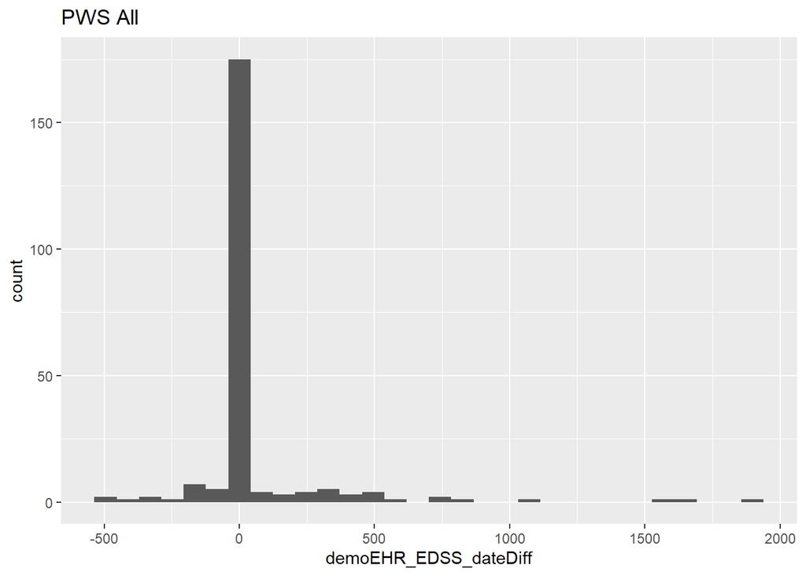

```r
p1 <- ggplot(data = zeno_pws_df, aes(demoEHR_EDSS_dateDiff)) +
  geom_histogram() +
  labs(title = "PWS All")
p1
```

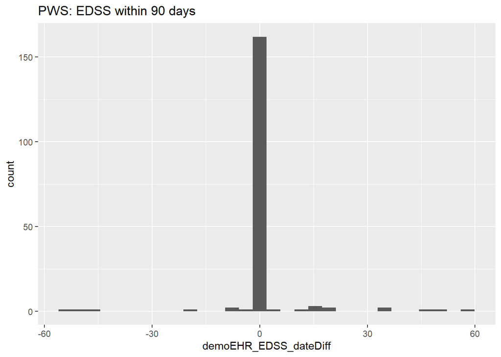

```r
# filter within 90 days
zeno_pws_edss_df <- zeno_pws_df %>%
  filter(demoEHR_EDSS_dateDiff > -90 & demoEHR_EDSS_dateDiff < 90)

p2 <- ggplot(data = zeno_pws_edss_df, aes(demoEHR_EDSS_dateDiff)) +
  geom_histogram() +
  labs(title = "PWS: EDSS within 90 days")
p2
```

```r
# Number of videos
print("# OF videos after dropping EDSS")
```

```
## [1] "# OF videos after dropping EDSS"
```

```r
print(nrow(zeno_pws_edss_df))
```

```
## [1] 181
```

```r
# select unique ID
zeno_pws_edss_df <- zeno_pws_edss_df %>%
  arrange(visit_date_video) %>%   # Sort by date
  distinct(bw_id, .keep_all = TRUE) %>%  # Keep the first occurrence of each ID
  drop_na(c("stride_time_median_sec_pose_zv", # drop missing video metrics
            "log_delta_pix_h_rel_median_pose_zv",
            "mean_cadence_step_per_min_pose_zv",
            "stride_width_median_cm_pose_zv"))
# Number of videos
print("# OF videos after dropping EDSS + only unique ID")
```

```
## [1] "# OF videos after dropping EDSS + only unique ID"
```

```r
print(nrow(zeno_pws_edss_df))
```

```
## [1] 101
```

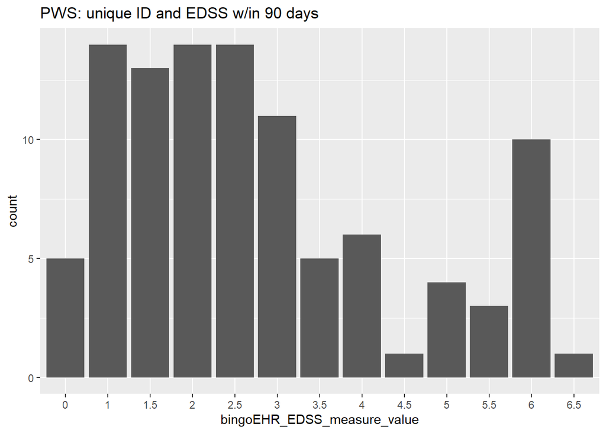

```r
# Histogram of EDSS: only unique ID
p3 <- ggplot(data = zeno_pws_edss_df, aes(bingoEHR_EDSS_measure_value)) +
  geom_bar() +
  labs(title = "PWS: unique ID and EDSS w/in 90 days ")
p3
```

### FW

```r
print("# of videos in original df")
```

```
## [1] "# of videos in original df"
```

```r
print(nrow(zeno_fw_df))
```

```
## [1] 222
```

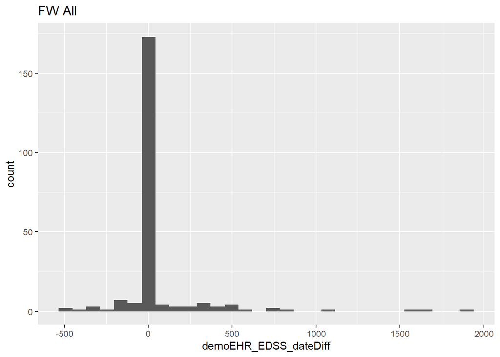

```r
p1 <- ggplot(data = zeno_fw_df, aes(demoEHR_EDSS_dateDiff)) +
  geom_histogram() +
  labs(title = "FW All")
p1
```

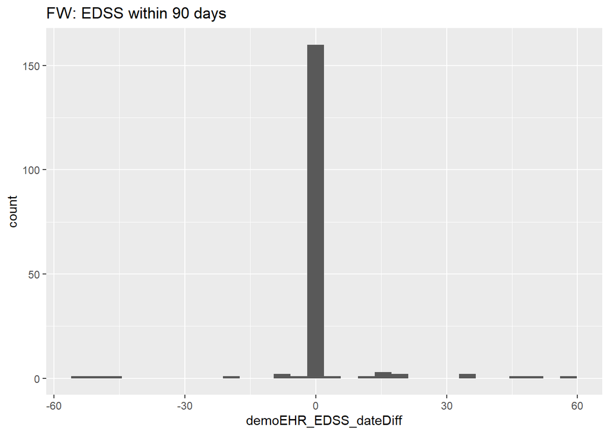

```r
# filter within 90 days
zeno_fw_edss_df <- zeno_fw_df %>%
  filter(demoEHR_EDSS_dateDiff > -90 & demoEHR_EDSS_dateDiff < 90)

p2 <- ggplot(data = zeno_fw_edss_df, aes(demoEHR_EDSS_dateDiff)) +
  geom_histogram() +
  labs(title = "FW: EDSS within 90 days")
p2
```

```r
# Number of videos
print("# OF videos after dropping EDSS")
```

```
## [1] "# OF videos after dropping EDSS"
```

```r
print(nrow(zeno_fw_edss_df))
```

```
## [1] 179
```

```r
# select unique ID
zeno_fw_edss_df <- zeno_fw_edss_df %>%
  arrange(visit_date_video) %>%   # Sort by date
  distinct(bw_id, .keep_all = TRUE)  %>%  # Keep the first occurrence of each ID
  drop_na(c("stride_time_median_sec_pose_zv", # drop missing video metrics
            "log_delta_pix_h_rel_median_pose_zv",
            "mean_cadence_step_per_min_pose_zv",
            "stride_width_median_cm_pose_zv"))

# Number of videos
print("# OF videos after dropping EDSS + only unique ID")
```

```
## [1] "# OF videos after dropping EDSS + only unique ID"
```

```r
print(nrow(zeno_fw_edss_df))
```

```
## [1] 100
```

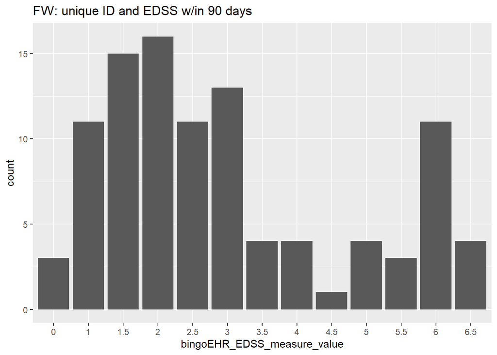

```r
# Histogram of EDSS: only unique ID
p3 <- ggplot(data = zeno_fw_edss_df, aes(bingoEHR_EDSS_measure_value)) +
  geom_bar() +
  labs(title = "FW: unique ID and EDSS w/in 90 days ")
p3
```

### Home

```r
print("# of videos in original df")
```

```
## [1] "# of videos in original df"
```

```r
print(nrow(home_df))
```

```
## [1] 65
```

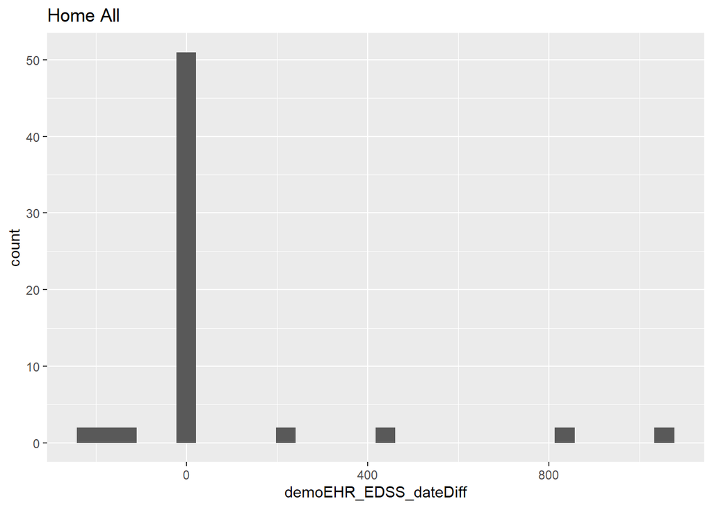

```r
p1 <- ggplot(data = home_df, aes(demoEHR_EDSS_dateDiff)) +
  geom_histogram() +
  labs(title = "Home All")
p1
```

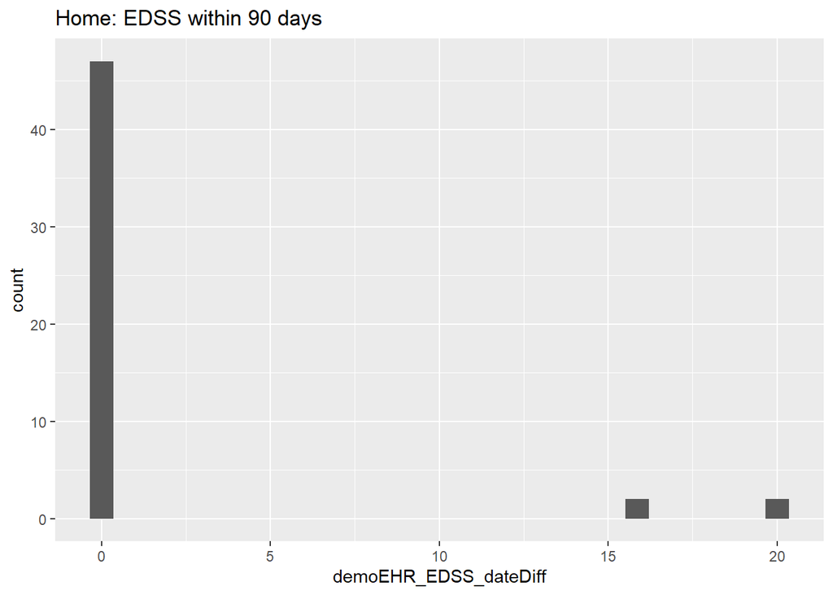

```r
# filter within 90 days
home_edss_df <- home_df %>%
  filter(demoEHR_EDSS_dateDiff > -90 & demoEHR_EDSS_dateDiff < 90)

p2 <- ggplot(data = home_edss_df, aes(demoEHR_EDSS_dateDiff)) +
  geom_histogram() +
  labs(title = "Home: EDSS within 90 days")
p2
```

```r
# Number of videos
print("# OF videos after dropping EDSS")
```

```
## [1] "# OF videos after dropping EDSS"
```

```r
print(nrow(home_edss_df))
```

```
## [1] 51
```

```r
# select unique ID
home_edss_df <- home_edss_df %>%
  arrange(visit_date_video) %>%   # Sort by date
  distinct(bw_id, .keep_all = TRUE)  %>%  # Keep the first occurrence of each ID
  drop_na(c("stride_time_median_sec_pose_hv", # drop missing video metrics
            "log_delta_pix_h_rel_median_pose_hv",
            "mean_cadence_step_per_min_pose_hv",
            "stride_width_median_cm_pose_hv"))

# Number of videos
print("# OF home_edss_df after dropping EDSS + only unique ID")
```

```
## [1] "# OF home_edss_df after dropping EDSS + only unique ID"
```

```r
print(nrow(home_edss_df))
```

```
## [1] 17
```

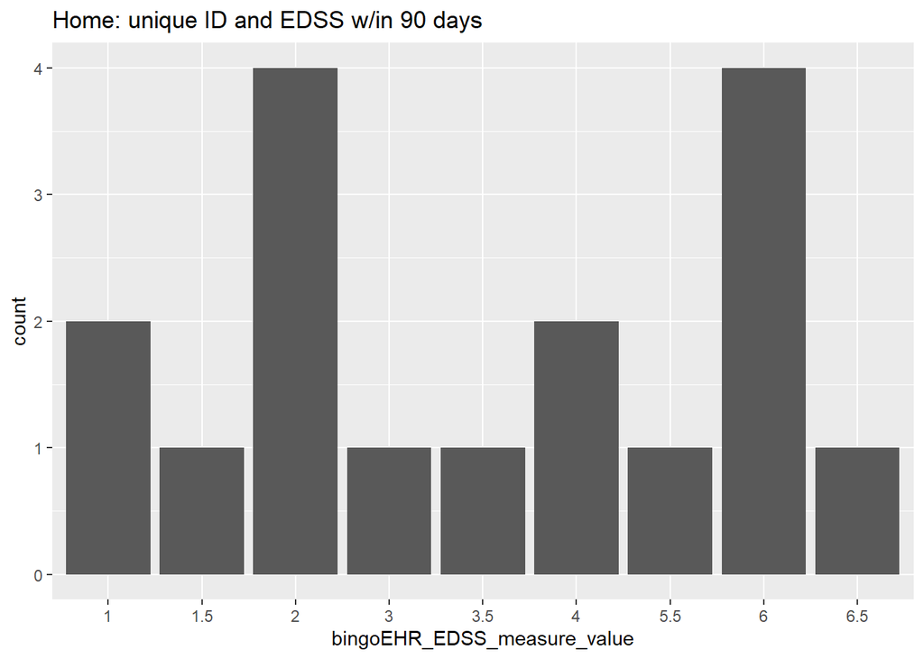

```r
# Histogram of EDSS: only unique ID
p3 <- ggplot(data = home_edss_df, aes(bingoEHR_EDSS_measure_value)) +
  geom_bar() +
  labs(title = "Home: unique ID and EDSS w/in 90 days ")
p3
```

## Check EDSS factor and levels

```r
print(str(zeno_pws_edss_df$edss_severity_cat))
```

```
##  Ord.factor w/ 3 levels "mild"<"moderate"<..: 2 2 3 2 1 2 1 1 1 2 ...
## NULL
```

```r
print(table(zeno_pws_edss_df$edss_severity_cat))
```

```
##
##     mild moderate   severe
##       46       36       19
```

```r
print(levels(zeno_pws_edss_df$edss_severity_cat))
```

```
## [1] "mild"     "moderate" "severe"
```

```r
print(str(zeno_fw_edss_df$edss_severity_cat))
```

```
##  Ord.factor w/ 3 levels "mild"<"moderate"<..: 2 2 2 3 2 1 2 1 3 1 ...
## NULL
```

```r
print(table(zeno_fw_edss_df$edss_severity_cat))
```

```
##
##     mild moderate   severe
##       45       32       23
```

```r
print(levels(zeno_fw_edss_df$edss_severity_cat))
```

```
## [1] "mild"     "moderate" "severe"
```

```r
print(str(home_df$edss_severity_cat))
```

```
##  Ord.factor w/ 3 levels "mild"<"moderate"<..: 2 2 2 2 2 2 3 3 3 3 ...
## NULL
```

```r
print(table(home_edss_df$edss_severity_cat))
```

```
##
##     mild moderate   severe
##        7        4        6
```

```r
print(levels(home_edss_df$edss_severity_cat))
```

```
## [1] "mild"     "moderate" "severe"
```

## Preferred Walking Speed Videos

### Univariate - log pixel proxy

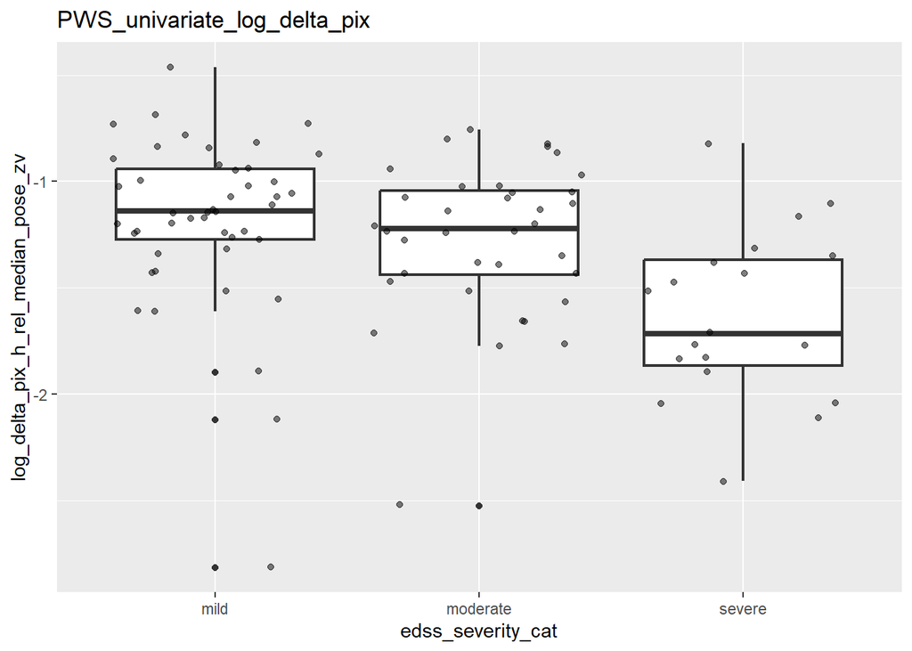

```r
# file name
filename = "PWS_univariate_log_delta_pix"
# plot
ggplot(zeno_pws_edss_df, aes(x = edss_severity_cat, y = log_delta_pix_h_rel_median_pose_zv)) +
  geom_boxplot(size = .75) +
  geom_jitter(alpha = .5) +
  labs(title = filename)
```

```r
ggsave(file.path(output_dir, paste(filename, 'vs_edss.png', sep = "_")))
# model
uni1 <- polr(edss_severity_cat ~ log_delta_pix_h_rel_median_pose_zv,
             data = zeno_pws_edss_df, Hess=TRUE)

summary_calc_p_and_odds(polr_object = uni1,
                        file_name = filename)
```

```
## Call:
## polr(formula = edss_severity_cat ~ log_delta_pix_h_rel_median_pose_zv,
##     data = zeno_pws_edss_df, Hess = TRUE)
##
## Coefficients:
##                                     Value Std. Error t value
## log_delta_pix_h_rel_median_pose_zv -1.919     0.5393  -3.558
##
## Intercepts:
##                 Value   Std. Error t value
## mild|moderate    2.2182  0.7018     3.1607
## moderate|severe  4.0686  0.7967     5.1069
##
## Residual Deviance: 195.7312
## AIC: 201.7312
## [1] "Add p-value"
##                                        Value Std. Error   t value      p.value
## log_delta_pix_h_rel_median_pose_zv -1.918786  0.5393079 -3.557867 3.738786e-04
## mild|moderate                       2.218190  0.7018020  3.160706 1.573871e-03
## moderate|severe                     4.068607  0.7966952  5.106855 3.275643e-07
```

```
##     2.5 %
## -3.025917
## [1] "Odds Ratio and CI"
##                                           OR    ci_2.5%  ci_97.5%
## log_delta_pix_h_rel_median_pose_zv 0.1467851 0.04851332 0.4061016
```

If significant effect: Test proportional odds assumption

```
## as.numeric(edss_severity_cat)      N= 101
##
## +----------------------------------+---------------+---+----+----+---------+
## |                                  |               |  N|Y>=1|Y>=2|     Y>=3|
## +----------------------------------+---------------+---+----+----+---------+
## |log_delta_pix_h_rel_median_pose_zv|[-2.813,-1.470)| 26| Inf|   0|-1.308684|
## |                                  |[-1.470,-1.204)| 25| Inf|   0|-1.791759|
## |                                  |[-1.204,-0.994)| 27| Inf|   0|-2.451621|
## |                                  |[-0.994,-0.462]| 23| Inf|   0|-2.462434|
## +----------------------------------+---------------+---+----+----+---------+
## |                           Overall|               |101| Inf|   0|-1.640972|
## +----------------------------------+---------------+---+----+----+---------+
```

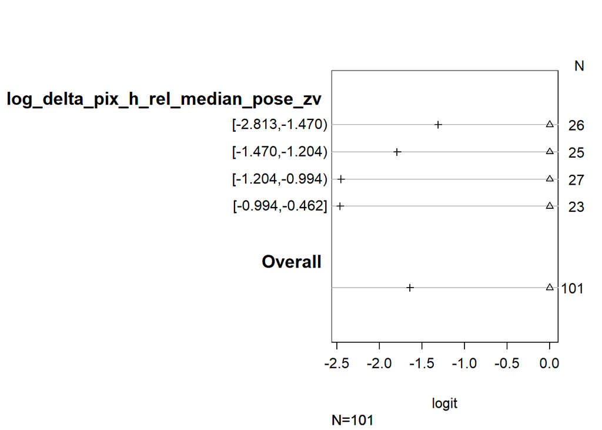

```r
# calculate the log odds of being greater than or equal to each value of the target variable
s <- with(zeno_pws_edss_df, summary(as.numeric(edss_severity_cat) ~ log_delta_pix_h_rel_median_pose_zv, fun=sf))
p <- plot_check_assumption(s_var = s)
```

Obtain and plot predicted probabilities

example newdat <- data.frame( pared = rep(0:1, 200), public = rep(0:1, each = 200), gpa = rep(seq(from = 1.9, to = 4, length.out = 100), 4))

Categorical vars (pared, public) - 0 and 1 levels for factor, repeat 01 200x = 400 rows Continuous vars (gpa_ - from = upper left square of s; to = lower right square of s length.out = 100 rows, * 4 = total 400 rows

```r
# Create new dataset of all values to use for prediction
newdat <- data.frame(
  log_delta_pix_h_rel_median_pose_zv = rep(seq(from = -2.813, to = -0.462, length.out = 100), 4))

# predict for each row of new dat using model
newdat <- cbind(newdat, predict(uni1, newdat, type = "probs"))
head(newdat)
```

```
##   log_delta_pix_h_rel_median_pose_zv       mild  moderate    severe
## 1                          -2.813000 0.03995011 0.1693852 0.7906647
## 2                          -2.789253 0.04173487 0.1752422 0.7830230
## 3                          -2.765505 0.04359574 0.1812227 0.7751816
## 4                          -2.741758 0.04553564 0.1873233 0.7671411
## 5                          -2.718010 0.04755757 0.1935400 0.7589024
## 6                          -2.694263 0.04966461 0.1998682 0.7504671
```

```r
# reshape for plotting
lnewdat <- melt(newdat, id.vars = c("log_delta_pix_h_rel_median_pose_zv"),
                variable.name = "Level", value.name="Probability")
head(lnewdat)
```

```
##   log_delta_pix_h_rel_median_pose_zv Level Probability
## 1                          -2.813000  mild  0.03995011
## 2                          -2.789253  mild  0.04173487
## 3                          -2.765505  mild  0.04359574
## 4                          -2.741758  mild  0.04553564
## 5                          -2.718010  mild  0.04755757
## 6                          -2.694263  mild  0.04966461
```

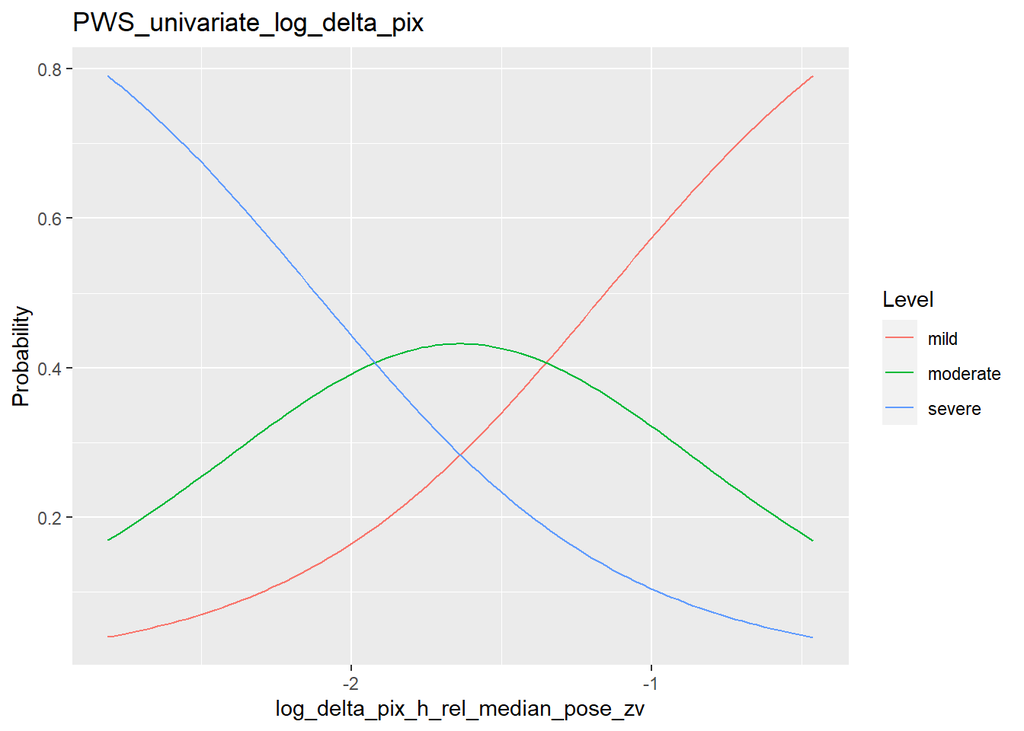

```r
# plot all of the predicted probabilities for the different conditions.
# example
#ggplot(lnewdat, aes(x = gpa, y = Probability, colour = Level)) +
  #geom_line() + facet_grid(pared ~ public, labeller="label_both")

p <- ggplot(lnewdat, aes(x = log_delta_pix_h_rel_median_pose_zv, y = Probability, colour = Level)) +
  geom_line() +
  labs(title = filename)
p
```

```r
ggsave(file.path(output_dir, paste(filename, "probabilities.png", sep = "_")))
```

### Univariate - stride_time_median_sec_pose

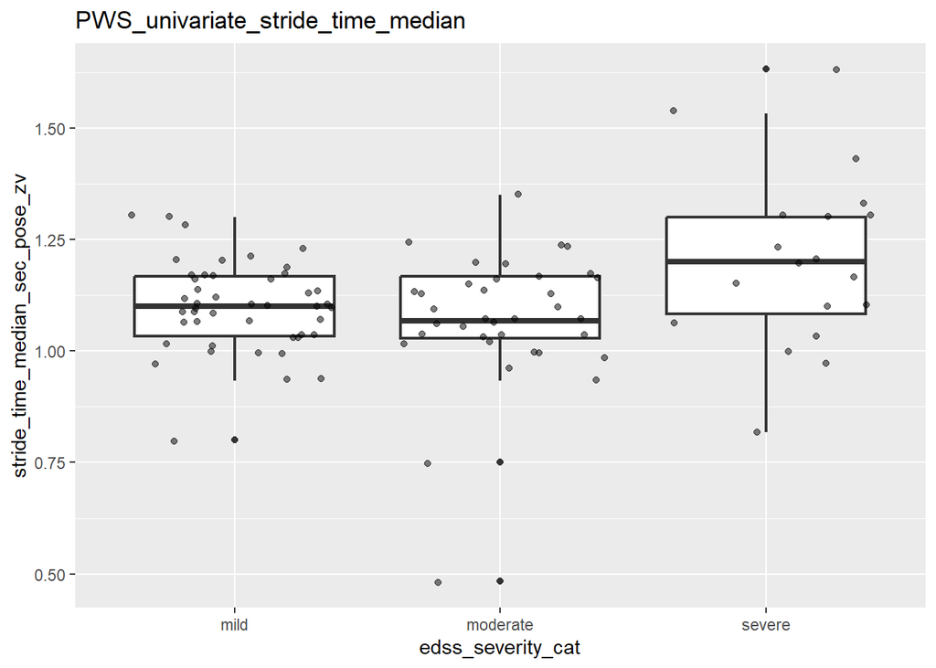

```r
filename = "PWS_univariate_stride_time_median"
# plot
ggplot(zeno_pws_edss_df, aes(x = edss_severity_cat, y = stride_time_median_sec_pose_zv)) +
  geom_boxplot(size = .75) +
  geom_jitter(alpha = .5) +
  labs(title = filename)
```

```r
ggsave(file.path(output_dir, paste(filename, 'vs_edss.png', sep = "_")))
# model
uni1 <- polr(edss_severity_cat ~ stride_time_median_sec_pose_zv,
             data = zeno_pws_edss_df, Hess=TRUE)

summary_calc_p_and_odds(polr_object = uni1,
                        file_name = filename)
```

```
## Call:
## polr(formula = edss_severity_cat ~ stride_time_median_sec_pose_zv,
##     data = zeno_pws_edss_df, Hess = TRUE)
##
## Coefficients:
##                                Value Std. Error t value
## stride_time_median_sec_pose_zv 2.515      1.401   1.795
##
## Intercepts:
##                 Value  Std. Error t value
## mild|moderate   2.5837 1.5580     1.6583
## moderate|severe 4.2732 1.6026     2.6665
##
## Residual Deviance: 206.7314
## AIC: 212.7314
## [1] "Add p-value"
##                                   Value Std. Error  t value     p.value
## stride_time_median_sec_pose_zv 2.515354   1.401181 1.795167 0.072627059
## mild|moderate                  2.583733   1.558035 1.658328 0.097251226
## moderate|severe                4.273214   1.602570 2.666475 0.007665132
```

```
##     2.5 %
## -0.161084
## [1] "Odds Ratio and CI"
##                                      OR   ci_2.5% ci_97.5%
## stride_time_median_sec_pose_zv 12.37099 0.8512206 217.5169
```

Stride time not significantly associated –> didn’t test assumptions etc

### Univariate - mean_cadence_step_per_min_pose

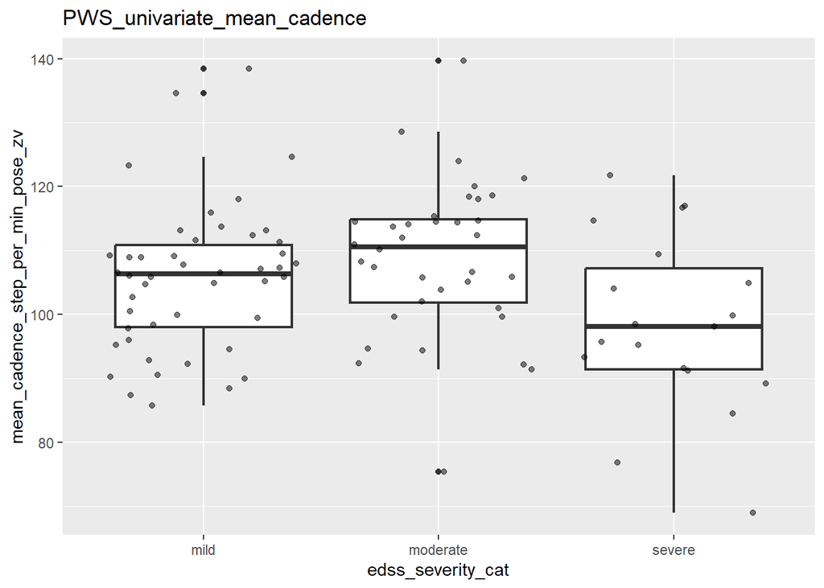

```r
filename = "PWS_univariate_mean_cadence"
# plot
ggplot(zeno_pws_edss_df, aes(x = edss_severity_cat, y = mean_cadence_step_per_min_pose_zv)) +
  geom_boxplot(size = .75) +
  geom_jitter(alpha = .5) +
  labs(title = filename)
```

```r
ggsave(file.path(output_dir, paste(filename, 'vs_edss.png', sep = "_")))
# model
uni1 <- polr(edss_severity_cat ~ mean_cadence_step_per_min_pose_zv,
             data = zeno_pws_edss_df, Hess=TRUE)

summary_calc_p_and_odds(polr_object = uni1,
                        file_name = filename)
```

```
## Call:
## polr(formula = edss_severity_cat ~ mean_cadence_step_per_min_pose_zv,
##     data = zeno_pws_edss_df, Hess = TRUE)
##
## Coefficients:
##                                      Value Std. Error t value
## mean_cadence_step_per_min_pose_zv -0.01752    0.01527  -1.148
##
## Intercepts:
##                 Value   Std. Error t value
## mild|moderate   -2.0459  1.6372    -1.2497
## moderate|severe -0.3876  1.6245    -0.2386
##
## Residual Deviance: 208.7933
## AIC: 214.7933
## [1] "Add p-value"
##                                         Value Std. Error    t value   p.value
## mean_cadence_step_per_min_pose_zv -0.01752039 0.01526761 -1.1475524 0.2511534
## mild|moderate                     -2.04594204 1.63715755 -1.2496916 0.2114122
## moderate|severe                   -0.38762242 1.62445874 -0.2386164 0.8114031
```

```
##       2.5 %
## -0.04785775
## [1] "Odds Ratio and CI"
##                                          OR   ci_2.5% ci_97.5%
## mean_cadence_step_per_min_pose_zv 0.9826322 0.9532694 1.012437
```

Cadence not significantly associated –> didn’t test assumptions etc

### Univariate - stride_width_median_cm_pose

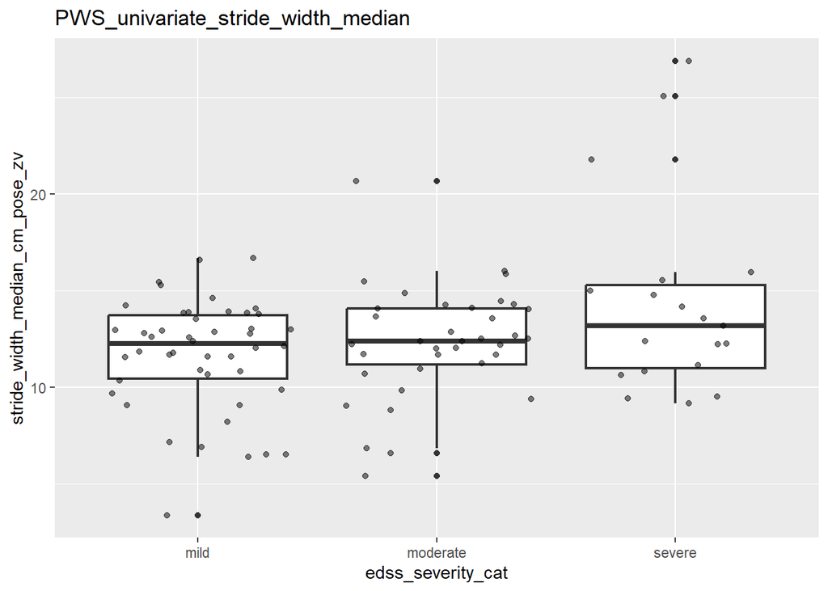

```r
filename = "PWS_univariate_stride_width_median"
# plot
ggplot(zeno_pws_edss_df, aes(x = edss_severity_cat, y = stride_width_median_cm_pose_zv)) +
  geom_boxplot(size = .75) +
  geom_jitter(alpha = .5) +
  labs(title = filename)
```

```r
ggsave(file.path(output_dir, paste(filename, 'vs_edss.png', sep = "_")))
# model
uni1 <- polr(edss_severity_cat ~ stride_width_median_cm_pose_zv,
             data = zeno_pws_edss_df, Hess=TRUE)

summary_calc_p_and_odds(polr_object = uni1,
                        file_name = filename)
```

```
## Call:
## polr(formula = edss_severity_cat ~ stride_width_median_cm_pose_zv,
##     data = zeno_pws_edss_df, Hess = TRUE)
##
## Coefficients:
##                                 Value Std. Error t value
## stride_width_median_cm_pose_zv 0.1535    0.05803   2.646
##
## Intercepts:
##                 Value  Std. Error t value
## mild|moderate   1.7014 0.7434     2.2888
## moderate|severe 3.4386 0.8039     4.2772
##
## Residual Deviance: 202.7472
## AIC: 208.7472
## [1] "Add p-value"
##                                   Value Std. Error  t value      p.value
## stride_width_median_cm_pose_zv 0.153519  0.0580257 2.645708 8.152019e-03
## mild|moderate                  1.701446  0.7433884 2.288771 2.209267e-02
## moderate|severe                3.438615  0.8039343 4.277234 1.892301e-05
```

```
##      2.5 %
## 0.04255108
## [1] "Odds Ratio and CI"
##                                     OR  ci_2.5% ci_97.5%
## stride_width_median_cm_pose_zv 1.16593 1.043469 1.314587
```

If significant effect: Test proportional odds assumption

```
## as.numeric(edss_severity_cat)      N= 101
##
## +------------------------------+------------+---+----+----+---------+
## |                              |            |  N|Y>=1|Y>=2|     Y>=3|
## +------------------------------+------------+---+----+----+---------+
## |stride_width_median_cm_pose_zv|[ 3.38,10.8)| 26| Inf|   0|-1.550597|
## |                              |[10.82,12.4)| 25| Inf|   0|-1.791759|
## |                              |[12.40,14.1)| 25| Inf|   0|-2.036882|
## |                              |[14.07,26.9]| 25| Inf|   0|-1.698233|
## +------------------------------+------------+---+----+----+---------+
## |                       Overall|            |101| Inf|   0|-1.640972|
## +------------------------------+------------+---+----+----+---------+
```

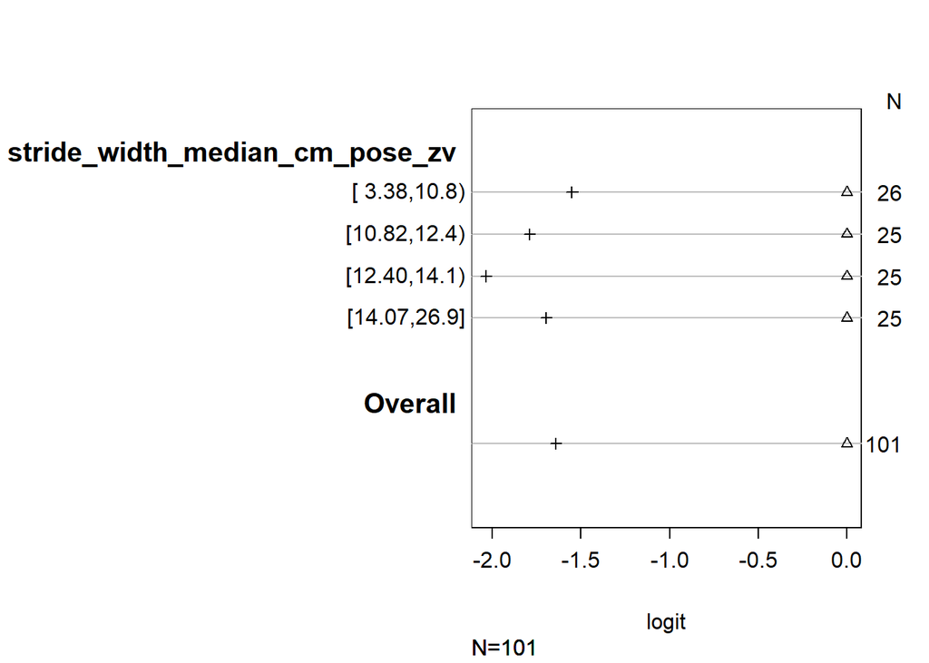

```r
# calculate the log odds of being greater than or equal to each value of the target variable
s <- with(zeno_pws_edss_df, summary(as.numeric(edss_severity_cat) ~ stride_width_median_cm_pose_zv, fun=sf))
plot_check_assumption(s_var = s)
```

```r
# Create new dataset of all values to use for prediction
newdat <- data.frame(
  stride_width_median_cm_pose_zv = rep(seq(from = 3.38, to = 26.9, length.out = 100), 4))

# predict for each row of new dat using model
newdat <- cbind(newdat, predict(uni1, newdat, type = "probs"))
head(newdat)
```

```
##   stride_width_median_cm_pose_zv      mild  moderate     severe
## 1                       3.380000 0.7654062 0.1834065 0.05118727
## 2                       3.617576 0.7587940 0.1882181 0.05298790
## 3                       3.855152 0.7520558 0.1930960 0.05484822
## 4                       4.092727 0.7451925 0.1980376 0.05676993
## 5                       4.330303 0.7382054 0.2030398 0.05875479
## 6                       4.567879 0.7310958 0.2080996 0.06080457
```

```r
# reshape for plotting
lnewdat <- melt(newdat, id.vars = c("stride_width_median_cm_pose_zv"),
                variable.name = "Level", value.name="Probability")
head(lnewdat)
```

```
##   stride_width_median_cm_pose_zv Level Probability
## 1                       3.380000  mild   0.7654062
## 2                       3.617576  mild   0.7587940
## 3                       3.855152  mild   0.7520558
## 4                       4.092727  mild   0.7451925
## 5                       4.330303  mild   0.7382054
## 6                       4.567879  mild   0.7310958
```

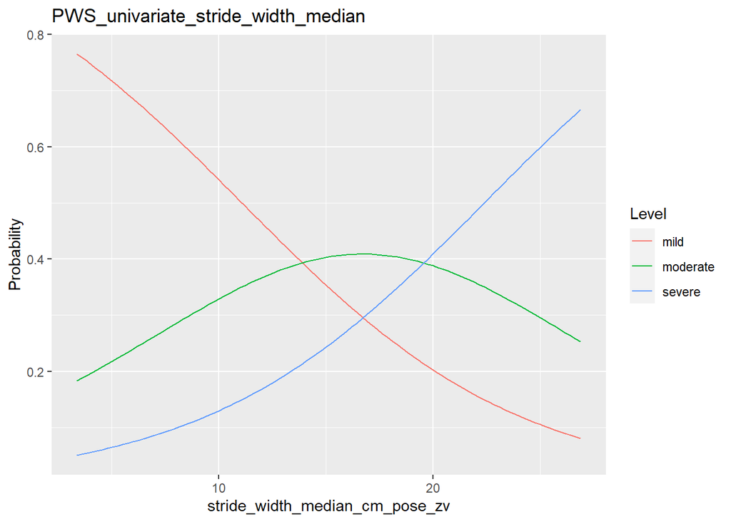

```r
# plot all of the predicted probabilities for the different conditions.
# example
#ggplot(lnewdat, aes(x = gpa, y = Probability, colour = Level)) +
  #geom_line() + facet_grid(pared ~ public, labeller="label_both")

ggplot(lnewdat, aes(x = stride_width_median_cm_pose_zv, y = Probability, colour = Level)) +
  geom_line() +
  labs(title = filename)
```

```r
ggsave(file.path(output_dir, paste(filename, "probabilities.png", sep = "_")))
```

### Univariate - demoEHR_Age

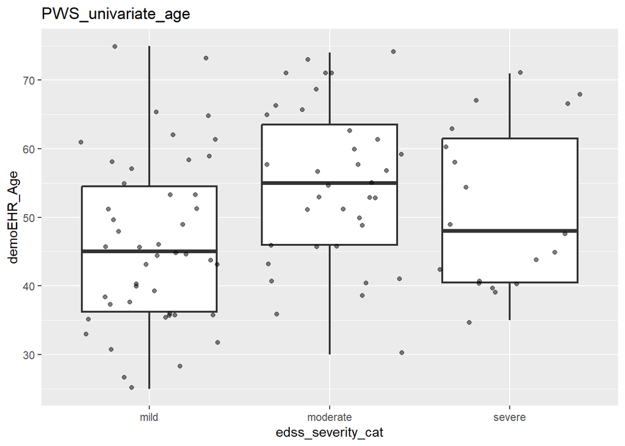

```r
filename = "PWS_univariate_age"
# plot
ggplot(zeno_pws_edss_df, aes(x = edss_severity_cat, y = demoEHR_Age)) +
  geom_boxplot(size = .75) +
  geom_jitter(alpha = .5) +
  labs(title = filename)
```

```r
ggsave(file.path(output_dir, paste(filename, 'vs_edss.png', sep = "_")))
# model
uni1 <- polr(edss_severity_cat ~ demoEHR_Age,
             data = zeno_pws_edss_df, Hess=TRUE)

summary_calc_p_and_odds(polr_object = uni1,
                        file_name = filename)
```

```
## Call:
## polr(formula = edss_severity_cat ~ demoEHR_Age, data = zeno_pws_edss_df,
##     Hess = TRUE)
##
## Coefficients:
##               Value Std. Error t value
## demoEHR_Age 0.03757    0.01577   2.383
##
## Intercepts:
##                 Value  Std. Error t value
## mild|moderate   1.7300 0.8281     2.0892
## moderate|severe 3.4440 0.8823     3.9035
##
## Residual Deviance: 204.239
## AIC: 210.239
## [1] "Add p-value"
##                      Value Std. Error  t value      p.value
## demoEHR_Age     0.03756552 0.01576563 2.382748 1.718395e-02
## mild|moderate   1.72995550 0.82806329 2.089159 3.669345e-02
## moderate|severe 3.44403544 0.88229155 3.903512 9.480695e-05
```

```
##       2.5 %
## 0.007132625
## [1] "Odds Ratio and CI"
##                  OR  ci_2.5% ci_97.5%
## demoEHR_Age 1.03828 1.007158 1.071662
```

If significant effect: Test proportional odds assumption - don’t think meets assumption?

```
## as.numeric(edss_severity_cat)      N= 101
##
## +-----------+-------+---+----+----+----------+
## |           |       |  N|Y>=1|Y>=2|      Y>=3|
## +-----------+-------+---+----+----+----------+
## |demoEHR_Age|[25,41)| 27| Inf|   0|-0.7884574|
## |           |[41,50)| 24| Inf|   0|-1.2656664|
## |           |[50,60)| 25| Inf|   0|-2.8478121|
## |           |[60,75]| 25| Inf|   0|-2.0971411|
## +-----------+-------+---+----+----+----------+
## |    Overall|       |101| Inf|   0|-1.6409721|
## +-----------+-------+---+----+----+----------+
```

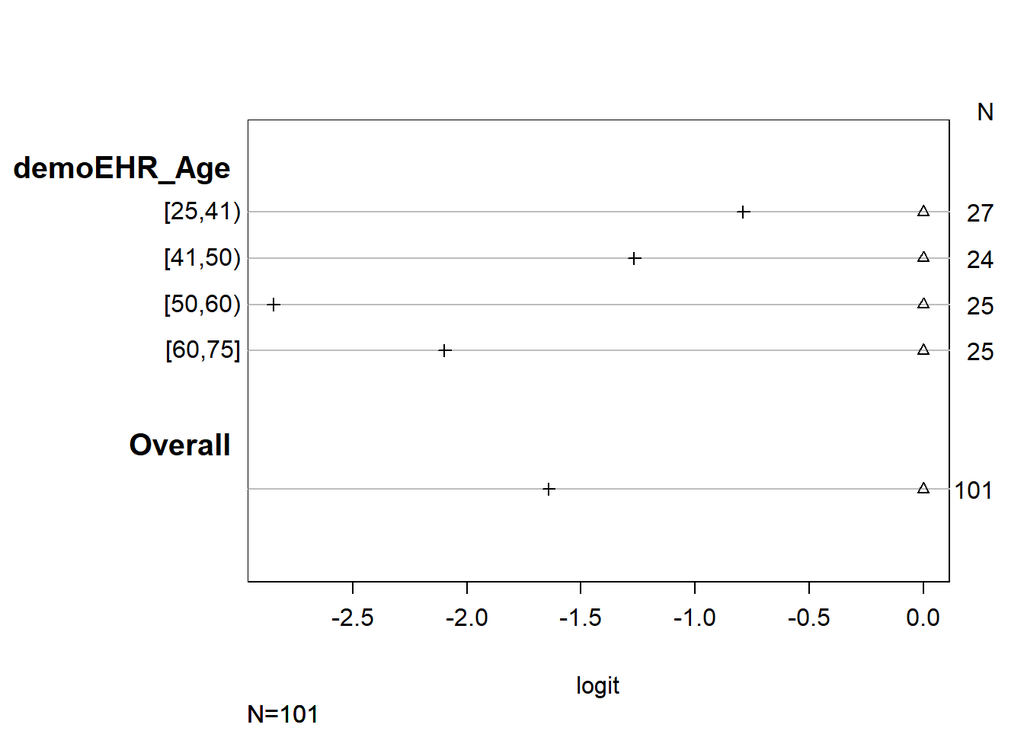

```r
# calculate the log odds of being greater than or equal to each value of the target variable
s <- with(zeno_pws_edss_df, summary(as.numeric(edss_severity_cat) ~ demoEHR_Age, fun=sf))
plot_check_assumption(s)
```

```r
# Create new dataset of all values to use for prediction
newdat <- data.frame(demoEHR_Age = rep(seq(from = 25, to = 75, length.out = 100), 4))

# predict for each row of new dat using model
newdat <- cbind(newdat, predict(uni1, newdat, type = "probs"))
head(newdat)
```

```
##   demoEHR_Age      mild  moderate     severe
## 1    25.00000 0.6880069 0.2364776 0.07551556
## 2    25.50505 0.6839199 0.2392293 0.07685079
## 3    26.01010 0.6798043 0.2419880 0.07820764
## 4    26.51515 0.6756606 0.2447531 0.07958639
## 5    27.02020 0.6714891 0.2475236 0.08098730
## 6    27.52525 0.6672904 0.2502990 0.08241066
```

```r
# reshape for plotting
lnewdat <- melt(newdat, id.vars = c("demoEHR_Age"),
                variable.name = "Level", value.name="Probability")
head(lnewdat)
```

```
##   demoEHR_Age Level Probability
## 1    25.00000  mild   0.6880069
## 2    25.50505  mild   0.6839199
## 3    26.01010  mild   0.6798043
## 4    26.51515  mild   0.6756606
## 5    27.02020  mild   0.6714891
## 6    27.52525  mild   0.6672904
```

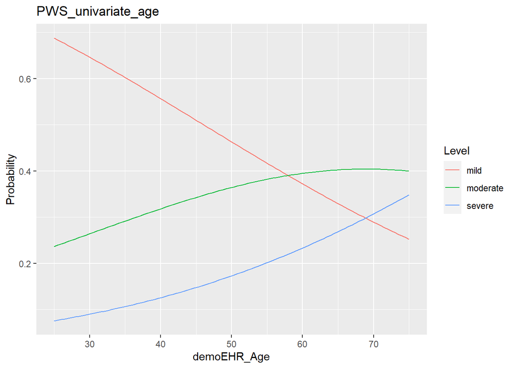

```r
# plot all of the predicted probabilities for the different conditions.
# example
#ggplot(lnewdat, aes(x = gpa, y = Probability, colour = Level)) +
  #geom_line() + facet_grid(pared ~ public, labeller="label_both")

ggplot(lnewdat, aes(x = demoEHR_Age, y = Probability, colour = Level)) +
  geom_line()  +
  labs(title = filename)
```

```r
ggsave(file.path(output_dir, paste(filename, 'probabilities.png', sep = "_")))
```

### Univariate - demoEHR_DiseaseDuration

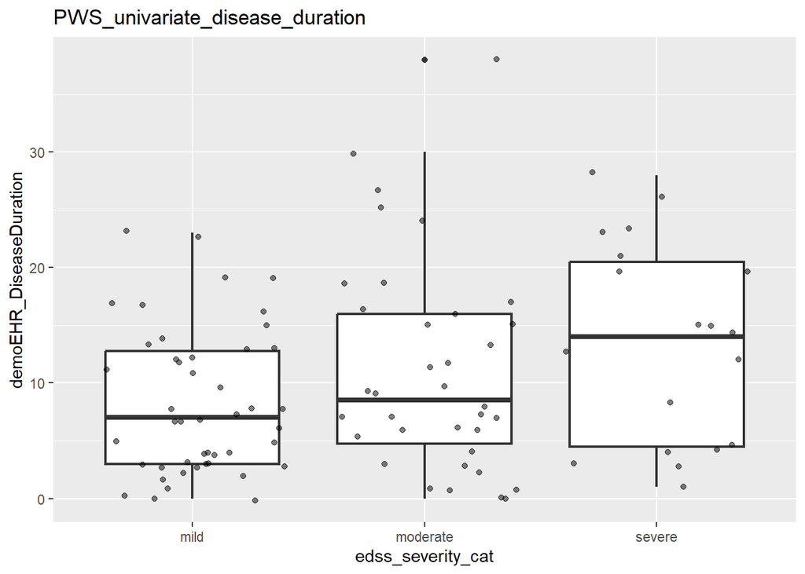

```r
filename = "PWS_univariate_disease_duration"
# plot
ggplot(zeno_pws_edss_df, aes(x = edss_severity_cat, y = demoEHR_DiseaseDuration)) +
  geom_boxplot(size = .75) +
  geom_jitter(alpha = .5) +
  labs(title = filename)
```

```r
ggsave(file.path(output_dir, paste(filename, 'vs_edss.png', sep = "_")))
# model
uni1 <- polr(edss_severity_cat ~ demoEHR_DiseaseDuration,
             data = zeno_pws_edss_df, Hess=TRUE)

summary_calc_p_and_odds(polr_object = uni1,
                        file_name = filename)
```

```
## Call:
## polr(formula = edss_severity_cat ~ demoEHR_DiseaseDuration, data = zeno_pws_edss_df,
##     Hess = TRUE)
##
## Coefficients:
##                           Value Std. Error t value
## demoEHR_DiseaseDuration 0.05669    0.02333    2.43
##
## Intercepts:
##                 Value  Std. Error t value
## mild|moderate   0.3900 0.3100     1.2579
## moderate|severe 2.1150 0.3833     5.5176
##
## Residual Deviance: 204.0244
## AIC: 210.0244
## [1] "Add p-value"
##                              Value Std. Error  t value      p.value
## demoEHR_DiseaseDuration 0.05668746 0.02333217 2.429583 1.511619e-02
## mild|moderate           0.38999127 0.31004198 1.257866 2.084402e-01
## moderate|severe         2.11499154 0.38331959 5.517567 3.437250e-08
```

```
##      2.5 %
## 0.01160241
## [1] "Odds Ratio and CI"
##                               OR ci_2.5% ci_97.5%
## demoEHR_DiseaseDuration 1.058325 1.01167 1.109161
```

If significant effect: Test proportional odds assumption - don’t think meets assumption?

```
## as.numeric(edss_severity_cat)      N= 101
##
## +-----------------------+-------+---+----+----+---------+
## |                       |       |  N|Y>=1|Y>=2|     Y>=3|
## +-----------------------+-------+---+----+----+---------+
## |demoEHR_DiseaseDuration|[ 0, 5)| 32| Inf|   0|-1.435085|
## |                       |[ 5, 9)| 21| Inf|   0|-2.346602|
## |                       |[ 9,16)| 24| Inf|   0|-1.502055|
## |                       |[16,38]| 24| Inf|   0|-1.774606|
## +-----------------------+-------+---+----+----+---------+
## |                Overall|       |101| Inf|   0|-1.640972|
## +-----------------------+-------+---+----+----+---------+
```

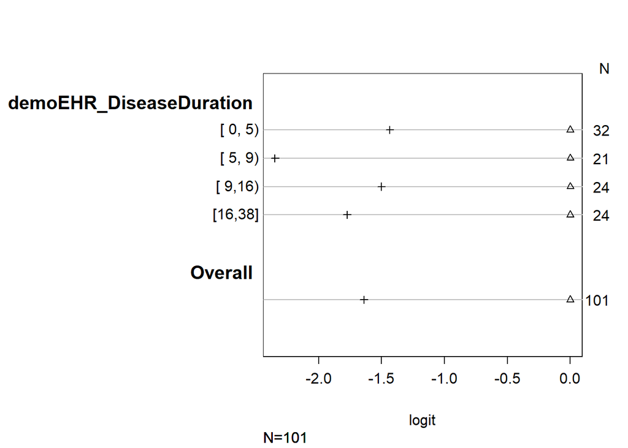

```r
# calculate the log odds of being greater than or equal to each value of the target variable
s <- with(zeno_pws_edss_df, summary(as.numeric(edss_severity_cat) ~ demoEHR_DiseaseDuration, fun=sf))
plot_check_assumption(s)
```

```r
# Create new dataset of all values to use for prediction
newdat <- data.frame(demoEHR_DiseaseDuration = rep(seq(from =0, to = 38, length.out = 100), 4))

# predict for each row of new dat using model
newdat <- cbind(newdat, predict(uni1, newdat, type = "probs"))
head(newdat)
```

```
##   demoEHR_DiseaseDuration      mild  moderate    severe
## 1               0.0000000 0.5962806 0.2960712 0.1076482
## 2               0.3838384 0.5910318 0.2992119 0.1097563
## 3               0.7676768 0.5857622 0.3023373 0.1119005
## 4               1.1515152 0.5804729 0.3054460 0.1140812
## 5               1.5353535 0.5751650 0.3085362 0.1162988
## 6               1.9191919 0.5698397 0.3116065 0.1185538
```

```r
# reshape for plotting
lnewdat <- melt(newdat, id.vars = c("demoEHR_DiseaseDuration"),
                variable.name = "Level", value.name="Probability")
head(lnewdat)
```

```
##   demoEHR_DiseaseDuration Level Probability
## 1               0.0000000  mild   0.5962806
## 2               0.3838384  mild   0.5910318
## 3               0.7676768  mild   0.5857622
## 4               1.1515152  mild   0.5804729
## 5               1.5353535  mild   0.5751650
## 6               1.9191919  mild   0.5698397
```

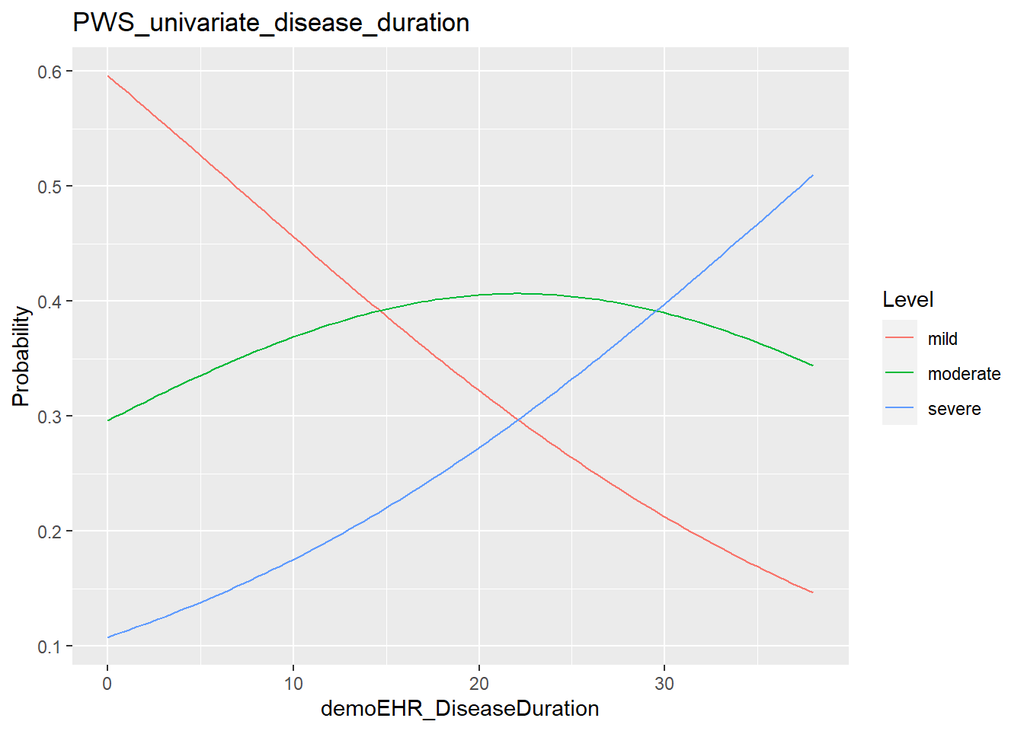

```r
# plot all of the predicted probabilities for the different conditions.
# example
#ggplot(lnewdat, aes(x = gpa, y = Probability, colour = Level)) +
  #geom_line() + facet_grid(pared ~ public, labeller="label_both")

ggplot(lnewdat, aes(x = demoEHR_DiseaseDuration, y = Probability, colour = Level)) +
  geom_line()  +
  labs(title = filename)
```

```r
ggsave(file.path(output_dir, paste(filename, 'probabilities.png', sep = "_")))
```

### Univariate - ms_dx_condensed

Using two groups: RRMS and not specified, or progressive

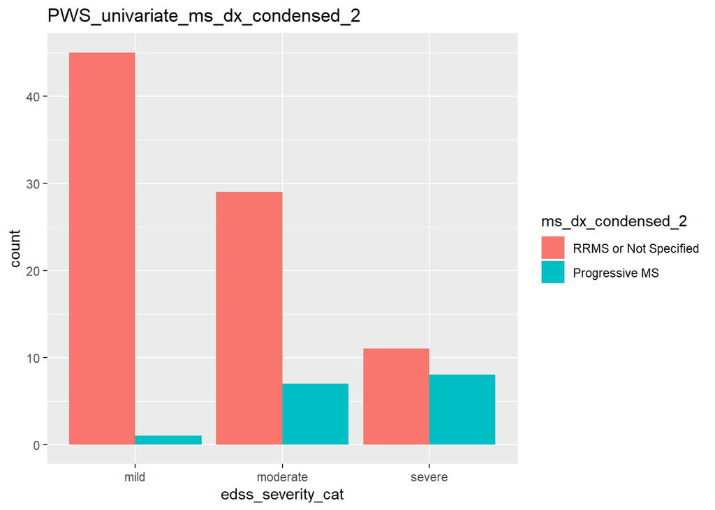

```r
filename = "PWS_univariate_ms_dx_condensed_2"

# plot
ggplot(zeno_pws_edss_df, aes(x = edss_severity_cat, fill = ms_dx_condensed_2)) +
  geom_bar(position = "dodge") +
  labs(title = filename)
```

```r
ggsave(file.path(output_dir, paste(filename, 'vs_edss.png', sep = "_")))
# model
uni1 <- polr(edss_severity_cat ~ ms_dx_condensed_2,
             data = zeno_pws_edss_df, Hess=TRUE)


summary_calc_p_and_odds(polr_object = uni1,
                        file_name = filename)
```

```
## Call:
## polr(formula = edss_severity_cat ~ ms_dx_condensed_2, data = zeno_pws_edss_df,
##     Hess = TRUE)
##
## Coefficients:
##                                 Value Std. Error t value
## ms_dx_condensed_2Progressive MS 2.116      0.546   3.876
##
## Intercepts:
##                 Value  Std. Error t value
## mild|moderate   0.0956 0.2171     0.4402
## moderate|severe 2.0002 0.3192     6.2670
##
## Residual Deviance: 193.7506
## AIC: 199.7506
## [1] "Add p-value"
##                                      Value Std. Error  t value      p.value
## ms_dx_condensed_2Progressive MS 2.11643566  0.5460349 3.876008 1.061841e-04
## mild|moderate                   0.09556713  0.2170816 0.440236 6.597662e-01
## moderate|severe                 2.00021145  0.3191646 6.267021 3.680207e-10
```

```
##    2.5 %
## 1.076356
## [1] "Odds Ratio and CI"
##                                       OR  ci_2.5% ci_97.5%
## ms_dx_condensed_2Progressive MS 8.301495 2.933969 25.36589
```

If significant effect: Test proportional odds assumption - don’t think meets assumption?

```
## as.numeric(edss_severity_cat)      N= 101
##
## +-----------------+---------------------+---+----+----+---------+
## |                 |                     |  N|Y>=1|Y>=2|     Y>=3|
## +-----------------+---------------------+---+----+----+---------+
## |ms_dx_condensed_2|RRMS or Not Specified| 85| Inf|   0|-1.788387|
## |                 |       Progressive MS| 16| Inf|   0|-2.708050|
## +-----------------+---------------------+---+----+----+---------+
## |          Overall|                     |101| Inf|   0|-1.640972|
## +-----------------+---------------------+---+----+----+---------+
```

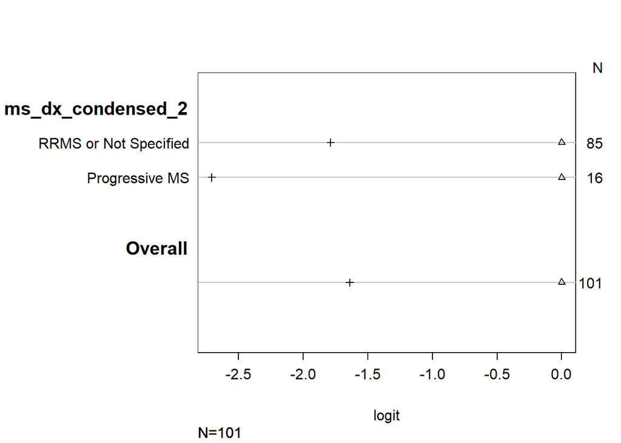

```r
# calculate the log odds of being greater than or equal to each value of the target variable
s <- with(zeno_pws_edss_df, summary(as.numeric(edss_severity_cat) ~ ms_dx_condensed_2, fun=sf))
plot_check_assumption(s)
```

### Univariate - race_ethnicity_clean

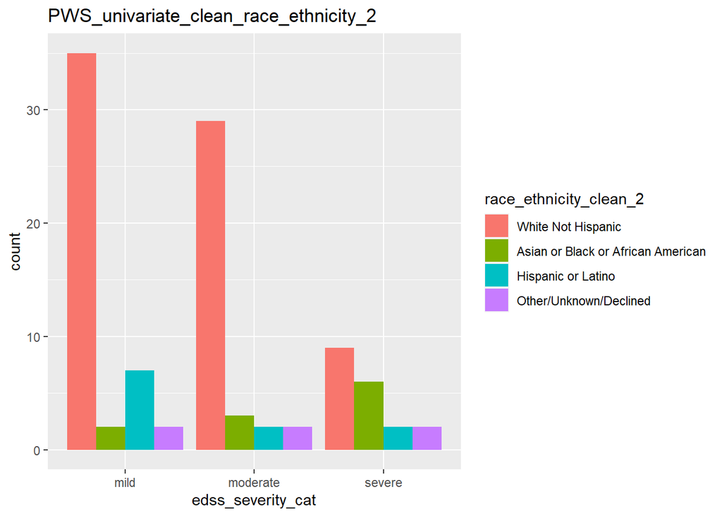

```r
filename = "PWS_univariate_clean_race_ethnicity_2"

# plot
ggplot(zeno_pws_edss_df, aes(x = edss_severity_cat, fill = race_ethnicity_clean_2)) +
  geom_bar(position = "dodge") +
  labs(title = filename)
```

```r
ggsave(file.path(output_dir, paste(filename, 'vs_edss.png', sep = "_")))
# model
uni1 <- polr(edss_severity_cat ~ race_ethnicity_clean_2,
             data = zeno_pws_edss_df, Hess=TRUE)


summary_calc_p_and_odds(polr_object = uni1,
                        file_name = filename)
```

```
## Call:
## polr(formula = edss_severity_cat ~ race_ethnicity_clean_2, data = zeno_pws_edss_df,
##     Hess = TRUE)
##
## Coefficients:
##                                                           Value Std. Error
## race_ethnicity_clean_2Asian or Black or African American  1.839     0.6524
## race_ethnicity_clean_2Hispanic or Latino                 -0.433     0.6675
## race_ethnicity_clean_2Other/Unknown/Declined              0.868     0.8129
##                                                          t value
## race_ethnicity_clean_2Asian or Black or African American  2.8184
## race_ethnicity_clean_2Hispanic or Latino                 -0.6487
## race_ethnicity_clean_2Other/Unknown/Declined              1.0678
##
## Intercepts:
##                 Value   Std. Error t value
## mild|moderate   -0.0274  0.2282    -0.1201
## moderate|severe  1.7634  0.3038     5.8052
##
## Residual Deviance: 200.0635
## AIC: 210.0635
## [1] "Add p-value"
##                                                                Value Std. Error
## race_ethnicity_clean_2Asian or Black or African American  1.83886314  0.6524414
## race_ethnicity_clean_2Hispanic or Latino                 -0.43300785  0.6674957
## race_ethnicity_clean_2Other/Unknown/Declined              0.86798584  0.8128657
## mild|moderate                                            -0.02740649  0.2282249
## moderate|severe                                           1.76341736  0.3037630
##                                                             t value
## race_ethnicity_clean_2Asian or Black or African American  2.8184342
## race_ethnicity_clean_2Hispanic or Latino                 -0.6487050
## race_ethnicity_clean_2Other/Unknown/Declined              1.0678097
## mild|moderate                                            -0.1200855
## moderate|severe                                           5.8052406
##                                                               p.value
## race_ethnicity_clean_2Asian or Black or African American 4.825850e-03
## race_ethnicity_clean_2Hispanic or Latino                 5.165290e-01
## race_ethnicity_clean_2Other/Unknown/Declined             2.856064e-01
## mild|moderate                                            9.044155e-01
## moderate|severe                                          6.427365e-09
```

```
## [1] 0.5893311
## [1] "Odds Ratio and CI"
##                                                                 OR  ci_2.5%
## race_ethnicity_clean_2Asian or Black or African American 6.2893841 1.802782
## race_ethnicity_clean_2Hispanic or Latino                 0.6485554 1.802782
## race_ethnicity_clean_2Other/Unknown/Declined             2.3821081 1.802782
##                                                           ci_97.5%
## race_ethnicity_clean_2Asian or Black or African American 0.1585708
## race_ethnicity_clean_2Hispanic or Latino                 0.1585708
## race_ethnicity_clean_2Other/Unknown/Declined             0.1585708
```

If significant effect: Test proportional odds assumption - don’t think meets assumption?

```
## as.numeric(edss_severity_cat)      N= 101
##
## +----------------------+----------------------------------+---+----+----+----------+
## |                      |                                  |  N|Y>=1|Y>=2|      Y>=3|
## +----------------------+----------------------------------+---+----+----+----------+
## |race_ethnicity_clean_2|                White Not Hispanic| 73| Inf|   0|-2.0438966|
## |                      |Asian or Black or African American| 11| Inf|   0|-1.3217558|
## |                      |                Hispanic or Latino| 11| Inf|   0|-0.9444616|
## |                      |            Other/Unknown/Declined|  6| Inf|   0|-1.3862944|
## +----------------------+----------------------------------+---+----+----+----------+
## |               Overall|                                  |101| Inf|   0|-1.6409721|
## +----------------------+----------------------------------+---+----+----+----------+
```

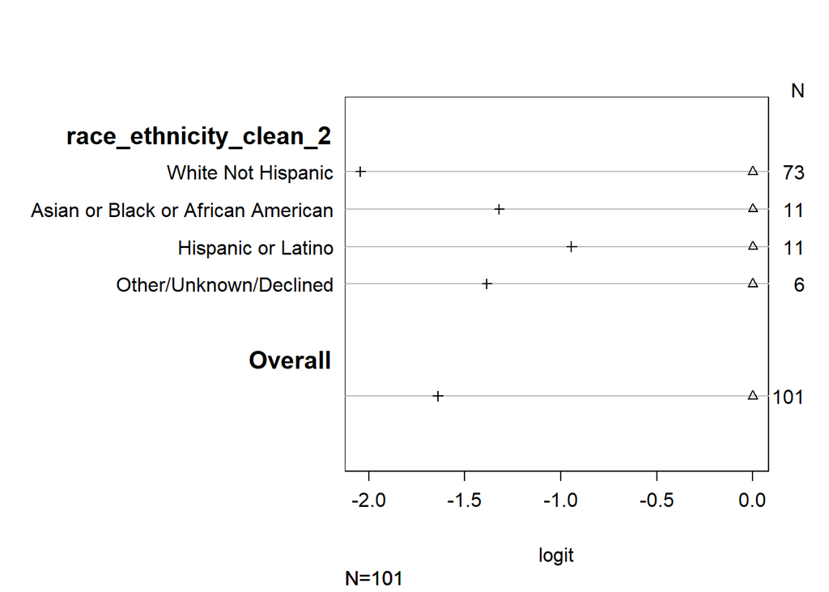

```r
# calculate the log odds of being greater than or equal to each value of the target variable
s <- with(zeno_pws_edss_df, summary(as.numeric(edss_severity_cat) ~ race_ethnicity_clean_2, fun=sf))
plot_check_assumption(s)
```

### Univariate - clean_sex

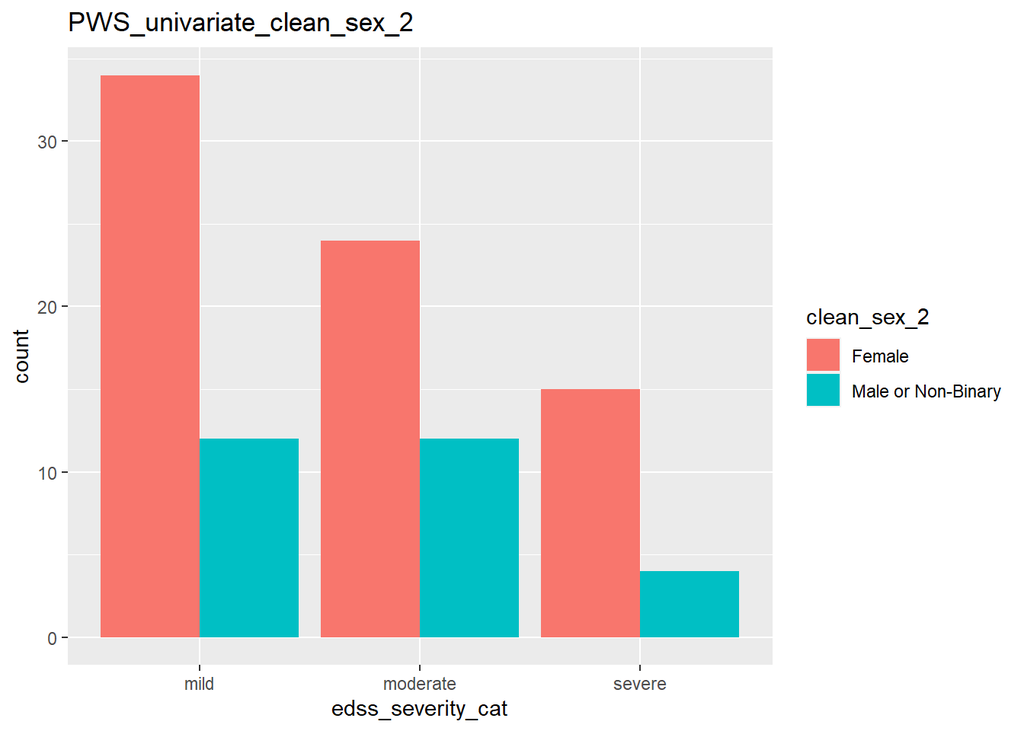

```r
filename = "PWS_univariate_clean_sex_2"

# plot
ggplot(zeno_pws_edss_df, aes(x = edss_severity_cat, fill = clean_sex_2)) +
  geom_bar(position = "dodge") +
  labs(title = filename)
```

```r
ggsave(file.path(output_dir, paste(filename, 'vs_edss.png', sep = "_")))
# model
uni1 <- polr(edss_severity_cat ~ clean_sex_2,
             data = zeno_pws_edss_df, Hess=TRUE)


summary_calc_p_and_odds(polr_object = uni1,
                        file_name = filename)
```

```
## Call:
## polr(formula = edss_severity_cat ~ clean_sex_2, data = zeno_pws_edss_df,
##     Hess = TRUE)
##
## Coefficients:
##                                  Value Std. Error  t value
## clean_sex_2Male or Non-Binary -0.01333     0.4103 -0.03249
##
## Intercepts:
##                 Value   Std. Error t value
## mild|moderate   -0.1826  0.2330    -0.7836
## moderate|severe  1.4584  0.2812     5.1863
##
## Residual Deviance: 210.1162
## AIC: 216.1162
## [1] "Add p-value"
##                                     Value Std. Error    t value      p.value
## clean_sex_2Male or Non-Binary -0.01333093  0.4103390 -0.0324876 9.740832e-01
## mild|moderate                 -0.18258760  0.2330232 -0.7835596 4.332985e-01
## moderate|severe                1.45839799  0.2812028  5.1862856 2.145297e-07
```

```
##      2.5 %
## -0.8267467
## [1] "Odds Ratio and CI"
##                                      OR   ci_2.5% ci_97.5%
## clean_sex_2Male or Non-Binary 0.9867575 0.4374702 2.200507
```

### Multivariate - Demographics and MS Info

```r
filename = "PWS_multivar_dem_ms_info"

# model
pws_multivar_dem_ms <- polr(edss_severity_cat ~ demoEHR_Age +
                              demoEHR_DiseaseDuration +
                              ms_dx_condensed_2 +
                              race_ethnicity_clean_2 +
                              clean_sex_2,
                            data = zeno_pws_edss_df, Hess=TRUE)


summary_calc_p_and_odds(polr_object = pws_multivar_dem_ms,
                        file_name = filename)
```

```
## Call:
## polr(formula = edss_severity_cat ~ demoEHR_Age + demoEHR_DiseaseDuration +
##     ms_dx_condensed_2 + race_ethnicity_clean_2 + clean_sex_2,
##     data = zeno_pws_edss_df, Hess = TRUE)
##
## Coefficients:
##                                                             Value Std. Error
## demoEHR_Age                                               0.02656    0.02043
## demoEHR_DiseaseDuration                                   0.03151    0.02858
## ms_dx_condensed_2Progressive MS                           2.07365    0.59632
## race_ethnicity_clean_2Asian or Black or African American  2.30838    0.69978
## race_ethnicity_clean_2Hispanic or Latino                 -0.09281    0.74089
## race_ethnicity_clean_2Other/Unknown/Declined              1.80181    0.90255
## clean_sex_2Male or Non-Binary                            -0.05313    0.45791
##                                                          t value
## demoEHR_Age                                               1.3001
## demoEHR_DiseaseDuration                                   1.1026
## ms_dx_condensed_2Progressive MS                           3.4774
## race_ethnicity_clean_2Asian or Black or African American  3.2987
## race_ethnicity_clean_2Hispanic or Latino                 -0.1253
## race_ethnicity_clean_2Other/Unknown/Declined              1.9963
## clean_sex_2Male or Non-Binary                            -0.1160
##
## Intercepts:
##                 Value   Std. Error t value
## mild|moderate    1.9937  1.0138     1.9665
## moderate|severe  4.2064  1.0899     3.8593
##
## Residual Deviance: 175.6375
## AIC: 193.6375
## [1] "Add p-value"
##                                                                Value Std. Error
## demoEHR_Age                                               0.02655731 0.02042785
## demoEHR_DiseaseDuration                                   0.03151428 0.02858252
## ms_dx_condensed_2Progressive MS                           2.07364565 0.59631553
## race_ethnicity_clean_2Asian or Black or African American  2.30837834 0.69978382
## race_ethnicity_clean_2Hispanic or Latino                 -0.09280781 0.74089290
## race_ethnicity_clean_2Other/Unknown/Declined              1.80181001 0.90255434
## clean_sex_2Male or Non-Binary                            -0.05312923 0.45790833
## mild|moderate                                             1.99369494 1.01383572
## moderate|severe                                           4.20636448 1.08992890
##                                                             t value
## demoEHR_Age                                               1.3000543
## demoEHR_DiseaseDuration                                   1.1025717
## ms_dx_condensed_2Progressive MS                           3.4774302
## race_ethnicity_clean_2Asian or Black or African American  3.2987021
## race_ethnicity_clean_2Hispanic or Latino                 -0.1252648
## race_ethnicity_clean_2Other/Unknown/Declined              1.9963452
## clean_sex_2Male or Non-Binary                            -0.1160259
## mild|moderate                                             1.9664872
## moderate|severe                                           3.8593017
##                                                               p.value
## demoEHR_Age                                              0.1935823644
## demoEHR_DiseaseDuration                                  0.2702132270
## ms_dx_condensed_2Progressive MS                          0.0005062448
## race_ethnicity_clean_2Asian or Black or African American 0.0009713294
## race_ethnicity_clean_2Hispanic or Latino                 0.9003139088
## race_ethnicity_clean_2Other/Unknown/Declined             0.0458963629
## clean_sex_2Male or Non-Binary                            0.9076320103
## mild|moderate                                            0.0492423618
## moderate|severe                                          0.0001137115
```

```
## [1] -0.01322788
## [1] "Odds Ratio and CI"
##                                                                  OR   ci_2.5%
## demoEHR_Age                                               1.0269131 0.9868592
## demoEHR_DiseaseDuration                                   1.0320161 0.9868592
## ms_dx_condensed_2Progressive MS                           7.9537670 0.9868592
## race_ethnicity_clean_2Asian or Black or African American 10.0581006 0.9868592
## race_ethnicity_clean_2Hispanic or Latino                  0.9113686 0.9868592
## race_ethnicity_clean_2Other/Unknown/Declined              6.0606073 0.9868592
## clean_sex_2Male or Non-Binary                             0.9482575 0.9868592
##                                                          ci_97.5%
## demoEHR_Age                                              0.976135
## demoEHR_DiseaseDuration                                  0.976135
## ms_dx_condensed_2Progressive MS                          0.976135
## race_ethnicity_clean_2Asian or Black or African American 0.976135
## race_ethnicity_clean_2Hispanic or Latino                 0.976135
## race_ethnicity_clean_2Other/Unknown/Declined             0.976135
## clean_sex_2Male or Non-Binary                            0.976135
```

If significant effect: Test proportional odds assumption - don’t think meets assumption?

```
## as.numeric(edss_severity_cat)      N= 101
##
## +-----------------------+----------------------------------+---+----+----+----------+
## |                       |                                  |  N|Y>=1|Y>=2|      Y>=3|
## +-----------------------+----------------------------------+---+----+----+----------+
## |            demoEHR_Age|                           [25,41)| 27| Inf|   0|-0.7884574|
## |                       |                           [41,50)| 24| Inf|   0|-1.2656664|
## |                       |                           [50,60)| 25| Inf|   0|-2.8478121|
## |                       |                           [60,75]| 25| Inf|   0|-2.0971411|
## +-----------------------+----------------------------------+---+----+----+----------+
## |demoEHR_DiseaseDuration|                           [ 0, 5)| 32| Inf|   0|-1.4350845|
## |                       |                           [ 5, 9)| 21| Inf|   0|-2.3466020|
## |                       |                           [ 9,16)| 24| Inf|   0|-1.5020552|
## |                       |                           [16,38]| 24| Inf|   0|-1.7746064|
## +-----------------------+----------------------------------+---+----+----+----------+
## |      ms_dx_condensed_2|             RRMS or Not Specified| 85| Inf|   0|-1.7883868|
## |                       |                    Progressive MS| 16| Inf|   0|-2.7080502|
## +-----------------------+----------------------------------+---+----+----+----------+
## | race_ethnicity_clean_2|                White Not Hispanic| 73| Inf|   0|-2.0438966|
## |                       |Asian or Black or African American| 11| Inf|   0|-1.3217558|
## |                       |                Hispanic or Latino| 11| Inf|   0|-0.9444616|
## |                       |            Other/Unknown/Declined|  6| Inf|   0|-1.3862944|
## +-----------------------+----------------------------------+---+----+----+----------+
## |            clean_sex_2|                            Female| 73| Inf|   0|-1.4895939|
## |                       |                Male or Non-Binary| 28| Inf|   0|-2.0794415|
## +-----------------------+----------------------------------+---+----+----+----------+
## |                Overall|                                  |101| Inf|   0|-1.6409721|
## +-----------------------+----------------------------------+---+----+----+----------+
```

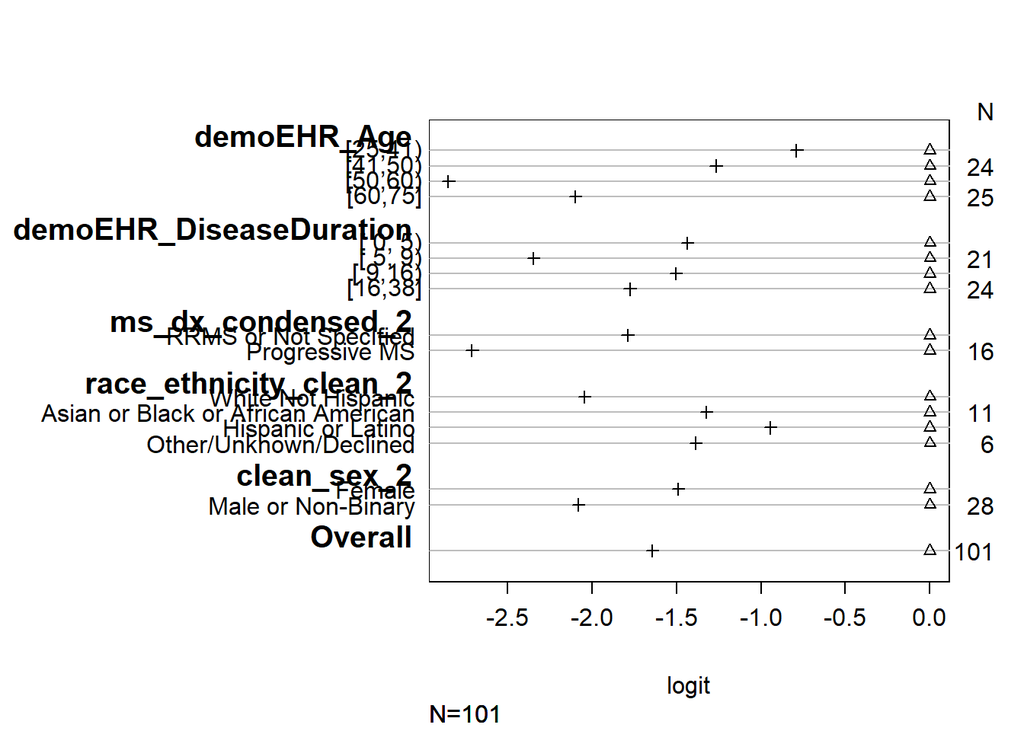

```r
# calculate the log odds of being greater than or equal to each value of the target variable
s <- with(zeno_pws_edss_df, summary(as.numeric(edss_severity_cat) ~ demoEHR_Age +
                                      demoEHR_DiseaseDuration +
                                      ms_dx_condensed_2 +
                                      race_ethnicity_clean_2 +
                                      clean_sex_2,
                                    fun=sf))
plot_check_assumption(s)
```

### Multivariate - Unadj Video Metrics

```r
filename = "PWS_multivar_video_unadj"

# model
pws_multivar_video_unadj <- polr(edss_severity_cat ~ log_delta_pix_h_rel_median_pose_zv +
                              stride_time_median_sec_pose_zv +
                              mean_cadence_step_per_min_pose_zv +
                              stride_width_median_cm_pose_zv,
                            data = zeno_pws_edss_df, Hess=TRUE)


summary_calc_p_and_odds(polr_object = pws_multivar_video_unadj,
                        file_name = filename)
```

```
## Call:
## polr(formula = edss_severity_cat ~ log_delta_pix_h_rel_median_pose_zv +
##     stride_time_median_sec_pose_zv + mean_cadence_step_per_min_pose_zv +
##     stride_width_median_cm_pose_zv, data = zeno_pws_edss_df,
##     Hess = TRUE)
##
## Coefficients:
##                                       Value Std. Error t value
## log_delta_pix_h_rel_median_pose_zv -1.90718    0.61418 -3.1052
## stride_time_median_sec_pose_zv      1.04720    1.80937  0.5788
## mean_cadence_step_per_min_pose_zv   0.02041    0.02048  0.9967
## stride_width_median_cm_pose_zv      0.13843    0.06198  2.2335
##
## Intercepts:
##                 Value   Std. Error t value
## mild|moderate    7.2154  3.8561     1.8712
## moderate|severe  9.1544  3.9005     2.3470
##
## Residual Deviance: 189.6073
## AIC: 201.6073
## [1] "Add p-value"
##                                          Value Std. Error    t value    p.value
## log_delta_pix_h_rel_median_pose_zv -1.90718142 0.61418391 -3.1052286 0.00190132
## stride_time_median_sec_pose_zv      1.04719993 1.80936628  0.5787661 0.56274699
## mean_cadence_step_per_min_pose_zv   0.02041179 0.02047972  0.9966829 0.31891844
## stride_width_median_cm_pose_zv      0.13842807 0.06197902  2.2334666 0.02551819
## mild|moderate                       7.21544591 3.85608289  1.8711854 0.06131939
## moderate|severe                     9.15437353 3.90052294  2.3469606 0.01892726
```

```
## [1] -3.17359
## [1] "Odds Ratio and CI"
##                                           OR   ci_2.5%   ci_97.5%
## log_delta_pix_h_rel_median_pose_zv 0.1484984 0.0418531 0.08698771
## stride_time_median_sec_pose_zv     2.8496607 0.0418531 0.08698771
## mean_cadence_step_per_min_pose_zv  1.0206215 0.0418531 0.08698771
## stride_width_median_cm_pose_zv     1.1484671 0.0418531 0.08698771
```

If significant effect: Test proportional odds assumption - don’t think meets assumption?

```
## as.numeric(edss_severity_cat)      N= 101
##
## +----------------------------------+---------------+---+----+----+----------+
## |                                  |               |  N|Y>=1|Y>=2|      Y>=3|
## +----------------------------------+---------------+---+----+----+----------+
## |log_delta_pix_h_rel_median_pose_zv|[-2.813,-1.470)| 26| Inf|   0|-1.3086838|
## |                                  |[-1.470,-1.204)| 25| Inf|   0|-1.7917595|
## |                                  |[-1.204,-0.994)| 27| Inf|   0|-2.4516207|
## |                                  |[-0.994,-0.462]| 23| Inf|   0|-2.4624338|
## +----------------------------------+---------------+---+----+----+----------+
## |    stride_time_median_sec_pose_zv|   [0.483,1.05)| 30| Inf|   0|-2.1400662|
## |                                  |   [1.050,1.12)| 25| Inf|   0|-1.7512681|
## |                                  |   [1.117,1.18)| 22| Inf|   0|-2.3025851|
## |                                  |   [1.183,1.63]| 24| Inf|   0|-1.0296194|
## +----------------------------------+---------------+---+----+----+----------+
## | mean_cadence_step_per_min_pose_zv|  [ 69.0, 97.8)| 26| Inf|   0|-0.9461437|
## |                                  |  [ 97.8,106.5)| 25| Inf|   0|-1.4663371|
## |                                  |  [106.5,113.7)| 25| Inf|   0|-2.6026897|
## |                                  |  [113.7,139.7]| 25| Inf|   0|-2.6026897|
## +----------------------------------+---------------+---+----+----+----------+
## |    stride_width_median_cm_pose_zv|   [ 3.38,10.8)| 26| Inf|   0|-1.5505974|
## |                                  |   [10.82,12.4)| 25| Inf|   0|-1.7917595|
## |                                  |   [12.40,14.1)| 25| Inf|   0|-2.0368819|
## |                                  |   [14.07,26.9]| 25| Inf|   0|-1.6982334|
## +----------------------------------+---------------+---+----+----+----------+
## |                           Overall|               |101| Inf|   0|-1.6409721|
## +----------------------------------+---------------+---+----+----+----------+
```

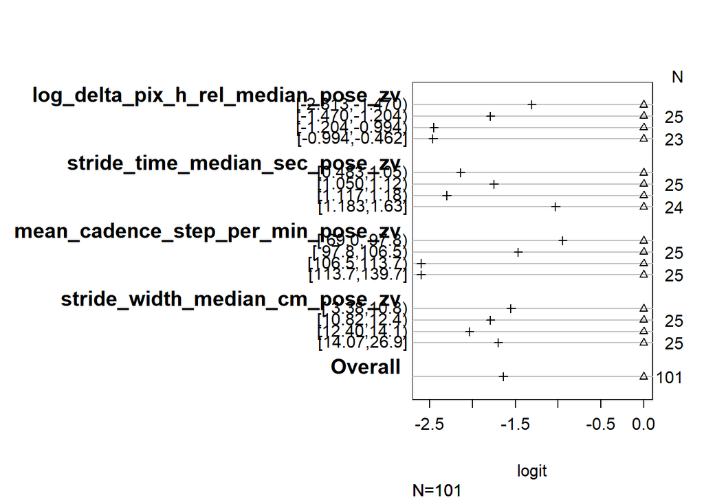

```r
# calculate the log odds of being greater than or equal to each value of the target variable
s <- with(zeno_pws_edss_df, summary(as.numeric(edss_severity_cat) ~ log_delta_pix_h_rel_median_pose_zv +
                                      stride_time_median_sec_pose_zv +
                                      mean_cadence_step_per_min_pose_zv +
                                      stride_width_median_cm_pose_zv,
                                    fun=sf))
plot_check_assumption(s)
```

### Multivariate - Adj Video Metrics

```r
filename = "PWS_multivar_video_adj"

# model
pws_multivar_video_adj <- polr(edss_severity_cat ~ demoEHR_Age +
                                   demoEHR_DiseaseDuration +
                                   ms_dx_condensed_2 +
                                   race_ethnicity_clean_2 +
                                   clean_sex_2 +
                                   log_delta_pix_h_rel_median_pose_zv +
                                   stride_time_median_sec_pose_zv +
                                   mean_cadence_step_per_min_pose_zv +
                                   stride_width_median_cm_pose_zv,
                                 data = zeno_pws_edss_df, Hess=TRUE)


summary_calc_p_and_odds(polr_object = pws_multivar_video_adj,
                        file_name = filename)
```

```
## Call:
## polr(formula = edss_severity_cat ~ demoEHR_Age + demoEHR_DiseaseDuration +
##     ms_dx_condensed_2 + race_ethnicity_clean_2 + clean_sex_2 +
##     log_delta_pix_h_rel_median_pose_zv + stride_time_median_sec_pose_zv +
##     mean_cadence_step_per_min_pose_zv + stride_width_median_cm_pose_zv,
##     data = zeno_pws_edss_df, Hess = TRUE)
##
## Coefficients:
##                                                             Value Std. Error
## demoEHR_Age                                               0.02753    0.02068
## demoEHR_DiseaseDuration                                   0.02964    0.02934
## ms_dx_condensed_2Progressive MS                           1.37203    0.66186
## race_ethnicity_clean_2Asian or Black or African American  2.37077    0.75025
## race_ethnicity_clean_2Hispanic or Latino                  0.22928    0.74054
## race_ethnicity_clean_2Other/Unknown/Declined              1.76961    0.93054
## clean_sex_2Male or Non-Binary                            -0.03467    0.47018
## log_delta_pix_h_rel_median_pose_zv                       -1.35893    0.67303
## stride_time_median_sec_pose_zv                            1.57865    2.00604
## mean_cadence_step_per_min_pose_zv                         0.01515    0.02257
## stride_width_median_cm_pose_zv                            0.05146    0.06959
##                                                           t value
## demoEHR_Age                                               1.33106
## demoEHR_DiseaseDuration                                   1.01013
## ms_dx_condensed_2Progressive MS                           2.07298
## race_ethnicity_clean_2Asian or Black or African American  3.15996
## race_ethnicity_clean_2Hispanic or Latino                  0.30962
## race_ethnicity_clean_2Other/Unknown/Declined              1.90170
## clean_sex_2Male or Non-Binary                            -0.07375
## log_delta_pix_h_rel_median_pose_zv                       -2.01911
## stride_time_median_sec_pose_zv                            0.78695
## mean_cadence_step_per_min_pose_zv                         0.67097
## stride_width_median_cm_pose_zv                            0.73950
##
## Intercepts:
##                 Value   Std. Error t value
## mild|moderate    7.6463  4.5047     1.6974
## moderate|severe  9.9695  4.5507     2.1908
##
## Residual Deviance: 168.8325
## AIC: 194.8325
```

[output cut: 28 more lines]

```
## moderate|severe                                           2.19076504
##                                                              p.value
## demoEHR_Age                                              0.183168689
## demoEHR_DiseaseDuration                                  0.312431365
## ms_dx_condensed_2Progressive MS                          0.038174371
## race_ethnicity_clean_2Asian or Black or African American 0.001577918
## race_ethnicity_clean_2Hispanic or Latino                 0.756852777
## race_ethnicity_clean_2Other/Unknown/Declined             0.057210309
## clean_sex_2Male or Non-Binary                            0.941211879
## log_delta_pix_h_rel_median_pose_zv                       0.043476045
## stride_time_median_sec_pose_zv                           0.431313043
## mean_cadence_step_per_min_pose_zv                        0.502238174
## stride_width_median_cm_pose_zv                           0.459600596
## mild|moderate                                            0.089619788
## moderate|severe                                          0.028468800
```

```
## [1] -0.01274096
## [1] "Odds Ratio and CI"
##                                                                  OR   ci_2.5%
## demoEHR_Age                                               1.0279089 0.9873399
## demoEHR_DiseaseDuration                                   1.0300844 0.9873399
## ms_dx_condensed_2Progressive MS                           3.9433309 0.9873399
## race_ethnicity_clean_2Asian or Black or African American 10.7056303 0.9873399
## race_ethnicity_clean_2Hispanic or Latino                  1.2576967 0.9873399
## race_ethnicity_clean_2Other/Unknown/Declined              5.8685878 0.9873399
## clean_sex_2Male or Non-Binary                             0.9659203 0.9873399
## log_delta_pix_h_rel_median_pose_zv                        0.2569365 0.9873399
## stride_time_median_sec_pose_zv                            4.8484078 0.9873399
## mean_cadence_step_per_min_pose_zv                         1.0152619 0.9873399
## stride_width_median_cm_pose_zv                            1.0528089 0.9873399
##                                                           ci_97.5%
## demoEHR_Age                                              0.9728128
## demoEHR_DiseaseDuration                                  0.9728128
## ms_dx_condensed_2Progressive MS                          0.9728128
## race_ethnicity_clean_2Asian or Black or African American 0.9728128
## race_ethnicity_clean_2Hispanic or Latino                 0.9728128
## race_ethnicity_clean_2Other/Unknown/Declined             0.9728128
## clean_sex_2Male or Non-Binary                            0.9728128
## log_delta_pix_h_rel_median_pose_zv                       0.9728128
## stride_time_median_sec_pose_zv                           0.9728128
## mean_cadence_step_per_min_pose_zv                        0.9728128
## stride_width_median_cm_pose_zv                           0.9728128
```

### Plot multivariate models

For now, just using combinations of three predictors, two categorical and one continuous Can try to edit to make continous vars categorical just for plots?

Plot 1 - Demographics only Left out sex - not sig effect in univariate Left out age - similar effect to duration, but expect disease duration to be more impactful on EDSS

```r
filename = "PWS_multivar_dur_dx_race"

# model
pws_multivar_dur_dx_race <- polr(edss_severity_cat ~ demoEHR_DiseaseDuration +
                              ms_dx_condensed_2 +
                              race_ethnicity_clean_2,
                            data = zeno_pws_edss_df, Hess=TRUE)


summary_calc_p_and_odds(polr_object = pws_multivar_dur_dx_race,
                        file_name = filename)
```

```
## Call:
## polr(formula = edss_severity_cat ~ demoEHR_DiseaseDuration +
##     ms_dx_condensed_2 + race_ethnicity_clean_2, data = zeno_pws_edss_df,
##     Hess = TRUE)
##
## Coefficients:
##                                                             Value Std. Error
## demoEHR_DiseaseDuration                                   0.04885    0.02564
## ms_dx_condensed_2Progressive MS                           2.17123    0.58971
## race_ethnicity_clean_2Asian or Black or African American  2.20225    0.70086
## race_ethnicity_clean_2Hispanic or Latino                 -0.33843    0.71328
## race_ethnicity_clean_2Other/Unknown/Declined              1.56401    0.86983
##                                                          t value
## demoEHR_DiseaseDuration                                   1.9054
## ms_dx_condensed_2Progressive MS                           3.6818
## race_ethnicity_clean_2Asian or Black or African American  3.1422
## race_ethnicity_clean_2Hispanic or Latino                 -0.4745
## race_ethnicity_clean_2Other/Unknown/Declined              1.7981
##
## Intercepts:
##                 Value   Std. Error t value
## mild|moderate    0.7996  0.3612     2.2138
## moderate|severe  2.9874  0.4913     6.0805
##
## Residual Deviance: 177.3528
## AIC: 191.3528
## [1] "Add p-value"
##                                                                Value Std. Error
## demoEHR_DiseaseDuration                                   0.04884576 0.02563575
## ms_dx_condensed_2Progressive MS                           2.17122505 0.58971183
## race_ethnicity_clean_2Asian or Black or African American  2.20225343 0.70085562
## race_ethnicity_clean_2Hispanic or Latino                 -0.33842517 0.71328052
## race_ethnicity_clean_2Other/Unknown/Declined              1.56400534 0.86982827
## mild|moderate                                             0.79957014 0.36116733
## moderate|severe                                           2.98735773 0.49129927
##                                                             t value
## demoEHR_DiseaseDuration                                   1.9053767
## ms_dx_condensed_2Progressive MS                           3.6818407
## race_ethnicity_clean_2Asian or Black or African American  3.1422355
## race_ethnicity_clean_2Hispanic or Latino                 -0.4744629
## race_ethnicity_clean_2Other/Unknown/Declined              1.7980622
## mild|moderate                                             2.2138496
## moderate|severe                                           6.0805255
##                                                               p.value
## demoEHR_DiseaseDuration                                  5.673112e-02
## ms_dx_condensed_2Progressive MS                          2.315561e-04
## race_ethnicity_clean_2Asian or Black or African American 1.676631e-03
## race_ethnicity_clean_2Hispanic or Latino                 6.351698e-01
## race_ethnicity_clean_2Other/Unknown/Declined             7.216715e-02
## mild|moderate                                            2.683913e-02
## moderate|severe                                          1.197893e-09
```

```
## [1] -0.0009176931
## [1] "Odds Ratio and CI"
##                                                                 OR   ci_2.5%
## demoEHR_DiseaseDuration                                  1.0500584 0.9990827
## ms_dx_condensed_2Progressive MS                          8.7690200 0.9990827
## race_ethnicity_clean_2Asian or Black or African American 9.0453737 0.9990827
## race_ethnicity_clean_2Hispanic or Latino                 0.7128921 0.9990827
## race_ethnicity_clean_2Other/Unknown/Declined             4.7779202 0.9990827
##                                                          ci_97.5%
## demoEHR_DiseaseDuration                                  2.857066
## ms_dx_condensed_2Progressive MS                          2.857066
## race_ethnicity_clean_2Asian or Black or African American 2.857066
## race_ethnicity_clean_2Hispanic or Latino                 2.857066
## race_ethnicity_clean_2Other/Unknown/Declined             2.857066
```

```
## as.numeric(edss_severity_cat)      N= 101
##
## +-----------------------+----------------------------------+---+----+----+----------+
## |                       |                                  |  N|Y>=1|Y>=2|      Y>=3|
## +-----------------------+----------------------------------+---+----+----+----------+
## |demoEHR_DiseaseDuration|                           [ 0, 5)| 32| Inf|   0|-1.4350845|
## |                       |                           [ 5, 9)| 21| Inf|   0|-2.3466020|
## |                       |                           [ 9,16)| 24| Inf|   0|-1.5020552|
## |                       |                           [16,38]| 24| Inf|   0|-1.7746064|
## +-----------------------+----------------------------------+---+----+----+----------+
## |      ms_dx_condensed_2|             RRMS or Not Specified| 85| Inf|   0|-1.7883868|
## |                       |                    Progressive MS| 16| Inf|   0|-2.7080502|
## +-----------------------+----------------------------------+---+----+----+----------+
## | race_ethnicity_clean_2|                White Not Hispanic| 73| Inf|   0|-2.0438966|
## |                       |Asian or Black or African American| 11| Inf|   0|-1.3217558|
## |                       |                Hispanic or Latino| 11| Inf|   0|-0.9444616|
## |                       |            Other/Unknown/Declined|  6| Inf|   0|-1.3862944|
## +-----------------------+----------------------------------+---+----+----+----------+
## |                Overall|                                  |101| Inf|   0|-1.6409721|
## +-----------------------+----------------------------------+---+----+----+----------+
```

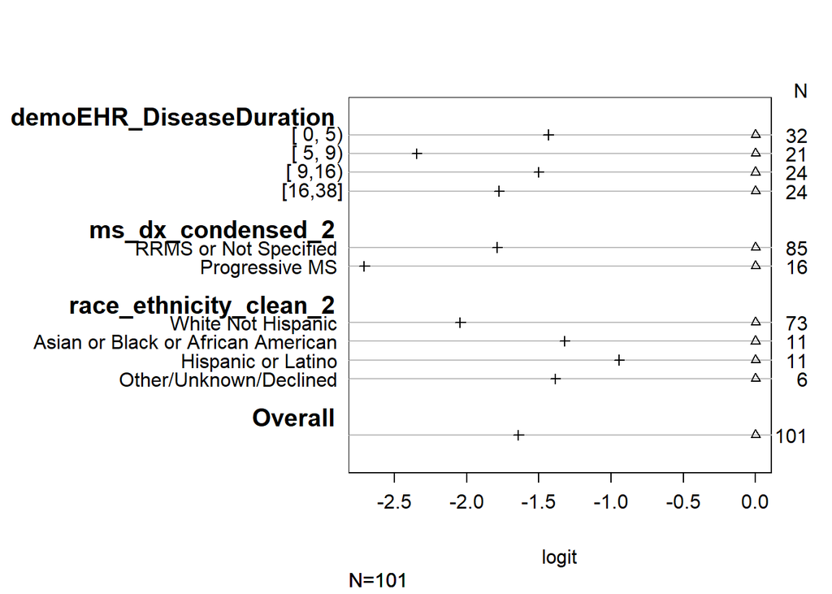

```r
# calculate the log odds of being greater than or equal to each value of the target variable
s <- with(zeno_pws_edss_df, summary(as.numeric(edss_severity_cat) ~ demoEHR_DiseaseDuration +
                                      ms_dx_condensed_2 +
                                      race_ethnicity_clean_2,
                                    fun=sf))
plot_check_assumption(s)
```